BVDOutbreakSize

Appearance

# Estimating the current size of the 2026 DRC Bundibugyo virus outbreak

**Authors:** Sam Abbott, Kath Sherratt, Samuel Brand and Sebastian Funk.

**Last updated:** 10 June 2026. This is a live report, re-run as new data arrive, so the estimates change between updates.

**Data as of:** 7 June 2026. DRC counts come from the situation reports of the Institut National de Santé Publique (INSP); Uganda imports come from WHO. The rendered report fills in the build date and the exact data cut-off automatically; the suspected-case and suspected-death streams, which carry most of the signal, were last published earlier than the laboratory-confirmed streams.

**See:** current outbreak size · one-week-ahead forecast · estimate evolution across releases · comparison with McCabe et al. · how the data streams compare · limitations · full joint results.

**Abstract.** An outbreak of Ebola disease caused by Bundibugyo virus (BVD) is ongoing in the Democratic Republic of the Congo (DRC), with cases also detected across the border in Uganda. This is a real-time joint Bayesian estimate of the current size of that outbreak, refreshed as new data arrive. Most infections are not yet reported, so the current size has to be inferred from the surveillance data that are available. The model is a discrete-time renewal process on a daily grid that fits the surveillance streams jointly in a single posterior: the DRC suspected cases, suspected deaths, laboratory-confirmed cases and confirmed deaths, and the cases and deaths exported to Uganda. It estimates the latent infections, symptom onsets and deaths over time, the reported and confirmed cases, and the time-varying reproduction number with its growth rate and doubling time, alongside the case-fatality ratio, the ascertainment of each surveillance system, and a short-term forecast of each stream over the coming week. The DRC data come from the INSP situation reports and the Uganda exports from the WHO situation reports and Disease Outbreak News, with a genetic bound on the time to the most recent common ancestor and priors taken from the McCabe et al. report.

**Scope.** This work is motivated by adding an external view of the current situation, based on our understanding of real-time infectious disease dynamics and the infection process that gives rise to observed epidemic surveillance counts. We are actively developing it and encourage feedback, so please get in touch. We fully support reuse and adaptation. Find out more in the contributing guide.

**Use of AI.** The model code and analysis were drafted by a language model and reviewed and revised under human oversight; the named authors are responsible for that oversight.

This page is generated from [`docs/examples/analysis.jl`](https://github.com/epiforecasts/BVDOutbreakSize/blob/main/docs/examples/analysis.jl); the model code it calls is in [`src/`](https://github.com/epiforecasts/BVDOutbreakSize/tree/main/src). See the *LLM-driven reimplementation* limitation below for the oversight context behind the Use of AI note.

**Offline copy.** A self-contained single-file HTML version of this report, built from the same run, is attached to each results release: [download the latest](https://github.com/epiforecasts/BVDOutbreakSize/releases/latest/download/analysis.html).

## Origins of this work

This work began as a replication of the McCabe et al. (McCabe and others, May 2026) report. It has since evolved into a real-time joint Bayesian estimate of the current outbreak size, a discrete-time renewal process with a time-varying reproduction number fitted to more of the available data streams than the original. The points below summarise how it now differs from the report; the Methods section carries the full treatment, and the later comparison with McCabe et al. sets the current estimates against theirs.

**Expand: differences from the report**

**Latent process and parameters**

- *Discrete-time renewal model.* The whole model runs on a daily grid. Infections follow the discrete renewal equation , where is the discretised generation-interval PMF, and every delay is applied as a discrete convolution. McCabe et al. (McCabe and others, May 2026) use continuous-time closed forms.
- *Time-varying reproduction number.* follows a weekly Gaussian random walk on the log scale, interpolated within weeks, with a logistic outbreak-response ramp of about three weeks at the first WHO situation report (18 May 2026). McCabe et al. use one constant exponential growth rate.
- *Joint posterior rather than scenario estimates.* The reproduction number, case-fatality ratio, all delays, traveller volume and surveillance dispersion have priors and are sampled together. McCabe et al. (McCabe and others, May 2026) fix each and report a set of scenarios.
- *Two-phase seeding with a wide, genetically-floored outbreak age.* A single import grows through an unobserved cryptic exponential phase to a magnitude set by a wide prior on the doubling count, at the growth rate the genetic estimate informs, before the renewal process takes over. The established reproduction number is derived forward from that growth rate. The genetic time to the most recent common ancestor floors the cryptic duration from below. McCabe et al. fix the start from a single seed.

**Delays and convolutions**

- *Delays re-estimated with uncertainty.* McCabe et al. (McCabe and others, May 2026) take the onset-to-death delay from the Isiro 2012 point estimate of Rosello et al. (Rosello and others, 2015). We instead use a Bayesian reanalysis of the same line list (Funk and Abbott, 2026) that re-estimates the delay with uncertainty, and we sample every other delay (generation interval, incubation period, onset-to-report, onset-to-confirmation and onset-to-detection abroad) from a prior centred on published Ebola estimates, discretised with double interval censoring (Charniga *et al.*, 2024), so the delay uncertainty propagates.

**Likelihoods and data streams**

**Extensions**

- *No-onward-transmission counterfactual and one-week-ahead forecasts.* Future expected deaths from infections already seeded, and a posterior-predictive projection of each stream.

## Limitations

The limitations are grouped by the data, the model assumptions and design, and the implementation, with the most consequential first in each group.

**Expand: limitations**

**Data and what it can support**

**Model assumptions and design**

- *Inherits McCabe et al.'s epidemiological assumptions.* A single zoonotic seed, an assumed generation interval, no spatial structure beyond the Ituri / Nord Kivu split, and no depletion of susceptibles. The onset-to-death delay is grounded on Isiro 2012 and the genetic seeding bound on an external clock rate, neither propagating cross-outbreak or clock uncertainty.
- *Intervention ramp is weakly identified.* With only a few sitreps straddling it, the ramp effect and the pre-ramp reproduction number are not well separated.

**Implementation**

- *LLM-driven reimplementation.* The model code, priors and analysis were drafted by a language model from the McCabe et al. (McCabe and others, May 2026) report and the companion delay reanalysis, then reviewed and revised. Not independently replicated against the authors' code.

**Load packages and seed the RNG**

julia

```julia
using Turing
using Distributions
using StatsFuns: logistic
using DataFrames: DataFrame
import CSV
using Random
using Markdown
using Dates: Date, Day, value
using BVDOutbreakSize
import CairoMakie

# Render figures at higher resolution so they stay crisp in the docs.
CairoMakie.activate!(type = "png", px_per_unit = 3)

Random.seed!(20260518)
```

```
Random.TaskLocalRNG()
```

## Methods

### Data

The DRC data come from the situation reports of the Institut National de Santé Publique (Institut National de Santé Publique and Centre des Opérations d'Urgence de Santé Publique (COUSP-RDC), May 2026). Each report gives the national cumulative suspected cases and deaths, laboratory-confirmed cases and deaths, and the specimens received and analysed by the laboratory, at the report date. We extracted these figures from the written situation-report PDFs (archived by INRB-UMIE (INRB-UMIE, 2026)) using a language model, with a second pass to re-read them, rather than the published per-zone CSVs. The zone sums in the CSVs are inconsistent with the national headline totals because they drop counts not yet attributed to a zone, so they understate the count. The Uganda data are the cases and the one death exported across the border, taken from the WHO situation reports and Disease Outbreak News (World Health Organization, May 2026). The cross-border traveller volume and source population come from McCabe et al. (McCabe and others, May 2026); the source population is fixed and the traveller volume is given a Normal prior around the McCabe et al. figure.

The first table lists each figure at the cut-off, or at the date reporting stopped for that stream. The second table gives the per-date history of each situation-report stream; the model fits the between-report increments of these series, so a single date reduces to the cut-off total.

**Loading observations and building the data table**

julia

```julia
obs = load_observations()
# Grid day-index (day n is the cut-off) back to a calendar date.
grid_date(day) = obs.cutoff - Day(obs.n - day)
# Date a cumulative history last reports (the cut-off for streams that
# run to it, or the freeze date for streams that stop earlier).
hist_last_date(h) = isempty(h.days) ? missing : grid_date(maximum(h.days))
observations_table = DataFrame(
    field = [
        "exported_cases",
        "exports_deaths",
        "suspected_deaths",
        "suspected_cases",
        "confirmed_cases",
        "confirmed_deaths",
        "specimens_analysed",
        "genetic_tmrca_bound",
        "daily_outbound_travellers (prior mean)",
        "daily_outbound_travellers_sd (prior SD)",
        "source_population"
    ],
    date = [
        isempty(obs.export_case_days) ? missing :
        grid_date(maximum(obs.export_case_days)),
        isempty(obs.export_death_days) ? missing :
        grid_date(maximum(obs.export_death_days)),
        hist_last_date(obs.deaths_history),
        hist_last_date(obs.reported_history),
        hist_last_date(obs.confirmed_history),
        hist_last_date(obs.confirmed_deaths_history),
        hist_last_date(obs.lab_history),
        grid_date(obs.n - obs.tmrca_days),
        missing,
        missing,
        missing
    ],
    value = [
        obs.exported_cases,
        obs.exports_deaths,
        obs.total_deaths,
        obs.reported_cases,
        obs.confirmed_cases,
        obs.confirmed_deaths,
        obs.tests_analysed,
        obs.tmrca_days,
        ITURI_DAILY_TRAVEL,
        ITURI_DAILY_TRAVEL_SD,
        ITURI_POPULATION
    ]
);
```

11×3 DataFrame

| Row | field String | date Date? | value Int64 |
| --- | --- | --- | --- |
| 1 | exported_cases | 2026-05-23 | 3 |
| 2 | exports_deaths | 2026-05-14 | 1 |
| 3 | suspected_deaths | 2026-05-26 | 246 |
| 4 | suspected_cases | 2026-05-26 | 1077 |
| 5 | confirmed_cases | 2026-06-07 | 550 |
| 6 | confirmed_deaths | 2026-06-07 | 101 |
| 7 | specimens_analysed | 2026-05-28 | 755 |
| 8 | genetic_tmrca_bound | 2026-03-25 | 74 |
| 9 | daily_outbound_travellers (prior mean) | missing | 1871 |
| 10 | daily_outbound_travellers_sd (prior SD) | missing | 200 |
| 11 | source_population | missing | 4392200 |

The per-date cumulative history of the DRC situation-report streams, the national totals at each report date. The joint model fits the between-report increments of these series, so a single date reduces to the cut-off total. See `data/observations.toml` for the per-stream sources.

**Building the per-date time-series table**

julia

```julia
vintage_table = let
    # Each history carries grid day-indices and counts; key the counts
    # by calendar date so every stream lines up in one table.
    bydate(h) = Dict(grid_date(d) => c for (d, c) in zip(h.days, h.counts))
    streams = (
        suspected_cases = bydate(obs.reported_history),
        suspected_deaths = bydate(obs.deaths_history),
        confirmed_cases = bydate(obs.confirmed_history),
        confirmed_deaths = bydate(obs.confirmed_deaths_history),
        specimens_received = bydate(obs.tests_received_history),
        specimens_analysed = bydate(obs.lab_history)
    )
    dates = sort(collect(union((keys(s) for s in streams)...)))
    at(s) = [haskey(s, d) ? s[d] : missing for d in dates]
    DataFrame(
        date = dates,
        suspected_cases = at(streams.suspected_cases),
        suspected_deaths = at(streams.suspected_deaths),
        confirmed_cases = at(streams.confirmed_cases),
        confirmed_deaths = at(streams.confirmed_deaths),
        specimens_received = at(streams.specimens_received),
        specimens_analysed = at(streams.specimens_analysed)
    )
end;
```

**Per-date situation-report data table**

21×7 DataFrame

| Row | date Date | suspected_cases Int64? | suspected_deaths Int64? | confirmed_cases Int64 | confirmed_deaths Int64? | specimens_received Int64? | specimens_analysed Int64? |
| --- | --- | --- | --- | --- | --- | --- | --- |
| 1 | 2026-05-18 | 516 | 131 | 33 | missing | missing | missing |
| 2 | 2026-05-19 | 575 | 148 | 51 | missing | missing | missing |
| 3 | 2026-05-20 | 672 | 160 | 57 | missing | missing | missing |
| 4 | 2026-05-21 | 745 | 175 | 79 | missing | missing | missing |
| 5 | 2026-05-22 | 872 | 204 | 83 | missing | missing | missing |
| 6 | 2026-05-23 | 904 | 220 | 101 | missing | 418 | 211 |
| 7 | 2026-05-24 | 906 | 223 | 105 | missing | 431 | 295 |
| 8 | 2026-05-25 | 998 | 238 | 106 | missing | 431 | 295 |
| 9 | 2026-05-26 | 1077 | 246 | 121 | 17 | 662 | 403 |
| 10 | 2026-05-27 | missing | missing | 125 | 17 | 774 | 648 |
| 11 | 2026-05-28 | missing | missing | 210 | 17 | 883 | 755 |
| 12 | 2026-05-29 | missing | missing | 263 | 42 | missing | missing |
| 13 | 2026-05-30 | missing | missing | 282 | 42 | missing | missing |
| 14 | 2026-05-31 | missing | missing | 321 | 48 | missing | missing |
| 15 | 2026-06-01 | missing | missing | 344 | 60 | missing | missing |
| 16 | 2026-06-02 | missing | missing | 363 | 62 | missing | missing |
| 17 | 2026-06-03 | missing | missing | 381 | 64 | missing | missing |
| 18 | 2026-06-04 | missing | missing | 452 | 82 | missing | missing |
| 19 | 2026-06-05 | missing | missing | 488 | 86 | missing | missing |
| 20 | 2026-06-06 | missing | missing | 515 | 91 | missing | missing |
| 21 | 2026-06-07 | missing | missing | 550 | 101 | missing | missing |

### Model

#### Model overview

We model a single outbreak seeded by a zoonotic introduction on a daily grid from a seeding date to the cut-off (day ). The generating infection process produces daily infection incidence via the discrete renewal equation

where is the discretised probability mass function (PMF) of the generation interval, indexed from lag 1 so an infectee is always infected strictly after its infector, and is the per-day reproduction number. A PMF gives the probability assigned to each whole-day lag. We never observe infections directly. Each data stream observes a thinned, delayed or transformed view of the same latent incidence. This is the class of time-varying renewal model used in EpiNow2 (Abbott *et al.*, 2020), with the streams fitted jointly here rather than in a pipeline.

The model is assembled from small reusable Turing (Ge *et al.*, 2018) submodels, each owning the maths and priors for one part of the generative process. We describe them in generative order, from the infection process through the epidemiological delays to the observation streams. The implementation uses Mooncake (Tebbutt and Ge, 2024) reverse-mode automatic differentiation, CensoredDistributions for delay discretisation, FlexiChains for chain handling, and PairPlots (Thompson, 2024) with AlgebraOfGraphics (Danisch and Krumbiegel, 2021) for the figures. Each submodel's source is shown in the collapsible block beneath its prose.

The table below shows which parameters inform each observation submodel. The *received* column is the received-specimen volume, the laboratory stream fitted as a count; the *confirmed* positives are scored as a Binomial of the observed analysed denominator with a positivity linked to the composition of the suspected pool, so the laboratory data help identify the non-BVD background. The *conf. deaths* column thins the suspected deaths by the case composition:

[output not shown]

#### Infections

The infection process is made up of several processes. There are the reproduction number, the generation interval that drives the renewal, the seeding that sets the initial infection count, the genetic bound on the outbreak age, the growth rate that fills the unobserved cryptic phase, and the renewal construction that grows the seed forward to the cut-off. Each is described in a subsection below.

##### Reproduction number

The reproduction number is assumed to follow a non-centred Gaussian random walk on the log scale, with knots at weekly intervals (day 1, 8, 15, …, ). The walk starts from the established reproduction number at the renewal start:

We do not place a prior on directly. We put the prior on the initial growth rate instead, given in the seeding and growth subsection below, and derive the established reproduction number forward from it through the Euler–Lotka relation under our generation interval :

The step-size prior keeps weekly changes in the reproduction number small. We set the half-normal on so that the reproduction number is unlikely to change by more than about 10% from one week to the next: two standard deviations of the weekly log-step is around .

Daily is the linear interpolation between the weekly knots, so the reproduction number varies piecewise linearly within each week:

with the day of knot . The outbreak response adds a sampled effect shaped by a logistic ramp at the first WHO situation report on 18 May 2026. We assume the response takes about three weeks (21 days) to take effect, and that it can only reduce transmission, so the effect is constrained to be non-positive:

**Submodel: rt_walk_model**

julia

```julia
@model function rt_walk_model(n::Integer, log_R0_base::Real;
        week::Integer = 7,
        breakpoint::Union{Missing, Real} = missing,
        rt_start::Integer = 1,
        ramp::Real = 21.0,
        sigma_prior = truncated(Normal(0, 0.05); lower = 0),
        effect_prior = truncated(Normal(0, 0.4); upper = 0))
    days = knot_days(n; week, start = rt_start)
    nb = length(days)
    ## The established `R0` at the genetic bound is the base the random walk
    ## grows from. It is DERIVED (forward Euler–Lotka from the sampled growth
    ## rate) and passed in, not sampled here; it is tracked as a deterministic
    ## so the walk base stays available on the chain. The days before the
    ## renewal start (`rt_start`) are filled by the analytic cryptic
    ## exponential in `infection_model`, so the walk values there are unused;
    ## the interpolation clamps to `log_R0` before the first knot, which is
    ## harmless.
    log_R0 := log_R0_base
    sigma_rw ~ sigma_prior
    z ~ product_distribution(fill(Normal(0, 1), max(nb - 1, 1)))
    intervention_effect ~ effect_prior
    steps = sigma_rw .* z[1:(nb - 1)]
    log_R = log_R0 .+ vcat(zero(log_R0), cumsum(steps))
    log_Rt = interpolate_knots(log_R, days, n)
    log_Rt = log_Rt .+ intervention_effect .* sigmoid_ramp(n, breakpoint; ramp)
    Rt = exp.(log_Rt)
    return (; Rt, log_R, days, sigma_rw, log_R0, intervention_effect)
end
```

##### Generation interval

We assume the generation interval is a Gamma distribution with a sampled shape and scale , taken from the Ebola virus disease serial interval used as a generation-time proxy (mean 15.3 d, SD 9.3 d; WHO Ebola Response Team 2014). That distribution maps once to a Gamma shape near and scale near , and the priors are centred on those values, with spreads that carry the source's reported uncertainty on the mean rather than a spread we assign ourselves:

The Gamma is discretised through the same double-interval-censoring route as every delay, described with the first epidemiological process model below, and the lag-0 bin is dropped and the remainder renormalised so the generation interval starts at one day and an infectee is infected strictly after its infector.

**Submodel: generation_interval_model**

julia

```julia
@model function generation_interval_model(nmax::Integer;
        alpha_prior = truncated(Normal(2.71, 0.7); lower = 0.1),
        theta_prior = truncated(Normal(5.65, 1.5); lower = 0.1))
    α ~ alpha_prior
    θ ~ theta_prior
    dist = Gamma(α, θ)
    pmf = discretise_censored(dist, nmax)
    g = pmf[2:end] ./ sum(pmf[2:end])
    return (; g, gi_mean = α * θ, gi_sd = sqrt(α) * θ,
        gi_alpha = α, gi_theta = θ)
end
```

##### Seeding and growth

From that seed we assume the outbreak grew deterministically through an unobserved cryptic exponential phase, doubling times before sustained transmission was established. The cryptic phase grows the seed to infections at the renewal start, the day the renewal takes over, over a duration with the doubling time. The doubling count has a wide prior centred on three cryptic doublings:

The growth rate carries the prior the genetic source informs. The genetic reanalysis reports the epidemic doubling time as 15.2 to 24.5 d across substitution-rate assumptions, with a centre near 20 d. We put a log-normal prior on equivalent to a log-normal prior on the doubling time centred on 20 d, with its log spread read from that range and inflated a little, so the prior is slightly wider in spread than the source but unbiased relative to it:

This single growth rate fills the cryptic phase and, through the forward Euler–Lotka derivation above, sets the established reproduction number, so the cryptic phase and the renewal share one growth source. The genetic report's own established reproduction number of about to uses its own generation interval; deriving forward from the shared growth rate under our generation interval is the consistent choice.

**Submodel: seed_model**

julia

```julia
@model function seed_model(; i0_prior = truncated(Normal(0.1, 0.1); lower = 0))
    I0 ~ i0_prior
    return (; I0)
end
```

**Submodel: exponential_growth_model**

julia

```julia
@model function exponential_growth_model(;
        r_prior = LogNormal(log(log(2) / M_PRIOR_DOUBLING_DAYS), 0.15),
        m_prior = truncated(Normal(M_PRIOR_BASE, 3.0); lower = 0))
    r ~ r_prior
    m ~ m_prior
    τ := log(2) / r
    T := m * τ
    C_T := 2.0^m
    return (; τ, r, m, T, C_T)
end
```

##### Genetic bound on outbreak age

A BEAST time tree of the first ten sequenced genomes (Amuri-Aziza *et al.*, 2026) places the TMRCA, the age of the oldest internal node of the tree, at a mean of 25 March 2026. The temporal sampling range is too short to estimate the molecular clock, so we fix it to the substitutions/site/year rate of the 2013-2016 West African Ebola epidemic (Holmes *et al.*, 2016). The TMRCA is a lower bound on the outbreak age. Adding sequences, or more geographically representative ones, can only push it earlier, never later, as the sampled tree is almost entirely from Bunia. Using the genetic TMRCA as a one-sided seeding bound rather than a point estimate follows a suggestion of N. Ferguson (Ferguson, 2026).

We treat the TMRCA day as a right-censored, noisy reading of the total outbreak age (the cryptic duration plus the observed window, defined in the infection process below):

The renewal starts on the grid day on which the renewal recursion begins and sustained transmission is treated as established. We place it 14 days after the genetic TMRCA day, past the molecular-clock uncertainty, so the observed window from the renewal start to the cut-off is shorter than the TMRCA age. The bound therefore stays informative on the cryptic duration, pulling the origin to sit at or before the most recent common ancestor and bounding the cryptic phase from below. It is one-sided, leaving the age free above the TMRCA. We fix the clock and do not propagate cross-outbreak or clock uncertainty.

**Submodel: genetic_seeding_model**

julia

```julia
@model function genetic_seeding_model(T::Real,
        tmrca_days::Union{Missing, Real}; tmrca_days_sd::Real = 15.0)
    if !ismissing(tmrca_days)
        tmrca_days ~ censored(Normal(T, tmrca_days_sd); upper = tmrca_days)
    end
    return (; T, tmrca_days_sd)
end
```

##### Infection process

The renewal start and observed window from the genetic bound above are

The grid days before the renewal start are filled by the cryptic exponential curve at rate ending at , giving the recursion a full generation interval of history. The renewal then grows the trajectory forward under the time-varying reproduction number. The total outbreak age is the cryptic duration plus the observed window:

Cumulative infections are the running sum of the daily infection series. The cumulative infection count at the cut-off is the headline outbreak size. The current growth rate is the day-over-day log-ratio of infections at the cut-off, and the current doubling time is divided by that rate.

**Submodel: infection_model**

julia

```julia
@model function infection_model(n::Integer;
        breakpoint::Union{Missing, Real} = missing,
        rt_start::Integer = 1,
        rt = rt_walk_model,
        gi = generation_interval_model,
        growth = exponential_growth_model,
        gi_nmax::Integer = cdf_nmax(Gamma(2.71, 5.65)))
    gi_state ~ to_submodel(gi(gi_nmax))
    g = gi_state.g
    ## ONE growth source: the prior is on the cryptic exponential growth rate
    ## `r` (sampled in `growth`), and the SINGLE established reproduction
    ## number `R0` (= the walk base, the first `R_t`) is derived FORWARD from
    ## that `r` and the generation interval through Euler–Lotka. The cryptic
    ## phase and the established renewal therefore share `r`.
    growth_state ~ to_submodel(growth())
    r_clock = growth_state.r
    R0 = r_to_R0(r_clock, g)
    rt_state ~ to_submodel(rt(n, log(R0); breakpoint, rt_start))
    Rt = rt_state.Rt
    ## renewal_start = genetic-TMRCA grid day (`rt_start`); the observation
    ## span is τ_obs = n − renewal_start. The renewal-start seed magnitude is
    ## `2^m` DIRECTLY (the cryptic phase grows one import to `2^m` over `m`
    ## doublings, `r`-free). Fill grid days 1…renewal_start with the cryptic
    ## exponential curve at rate `r` ending at `2^m` (a full GI of history),
    ## then run the renewal forward from renewal_start+1.
    renewal_start = clamp(rt_start, 1, n)
    τ_obs = n - renewal_start
    seed0 = seed_at_renewal_start(growth_state.C_T)
    seed_vec = seed_infections(seed0, r_clock, renewal_start)
    infections = renewal_infections(Rt, g, seed_vec)
    cumulative = cumsum(infections)
    ## Total outbreak age: cryptic duration (m·τ) plus the observation span.
    T_total = growth_state.T + τ_obs
    ## Realized current growth rate from the last two days; n ≥ 2 in
    ## practice, with a zero-growth fallback on a degenerate single-day grid.
    r = n >= 2 ?
        log(safe_rate(infections[n])) - log(safe_rate(infections[n - 1])) :
        zero(@inbounds infections[begin])
    return (; infections, cumulative, Rt, g, seed_at_renewal_start = seed0,
        m = growth_state.m, τ = growth_state.τ, R0, r0 = r_clock, r,
        doubling_time_initial = doubling_time(r_clock),
        T = T_total, C_T = cumulative[n],
        C_T_prior = growth_state.C_T, doubling_time = doubling_time(r),
        seeding_age = seeding_age(cumulative, n))
end
```

#### Epidemiological process models

We model each observed stream as a delayed and thinned view of the daily onset incidence. This section gives the delays that map infections to onsets and onsets to each observed endpoint, and the case-fatality ratio that maps onsets to deaths. The incubation period comes first, then the onset-to-report delay (also used for export detection), the onset-to-death delay and the report-to-receipt delay, then the case-fatality ratio.

##### Incubation period

Infections are convolved with the incubation-period PMF to give daily symptom-onset incidence, computed once and consumed by every downstream observation stream. We use the Bundibugyo virus incubation-period estimate from the 2007 Uganda outbreak (mean 6.3 d, 95% CI 5.2-7.3, ; (MacNeil *et al.*, 2010)). The mean prior reproduces that 95% CI; the source reports no interval on the spread, so the SD prior is our own choice:

Every delay is discretised to a daily PMF over lags by double interval censoring (Charniga *et al.*, 2024). The delays the companion line-list reanalysis reports — the onset-to-admission delay (used for both suspected-case reporting and export detection) and the two onset-to-death components — are carried through on their natural Gamma shape and scale, with the reanalysis's reported uncertainty, like the generation interval above. The incubation period and the laboratory receipt delay are not in the line list, so they keep a mean-and-SD prior moment-matched to a LogNormal. The LogNormal and Gamma CDFs both differentiate cleanly under the reverse-mode automatic differentiation. The maximum lag is not hand-set: for each delay it is the 98th percentile of the prior-centre distribution, computed once outside the model, so every delay captures a consistent 98% of its mass before the truncated PMF is renormalised.

Both the primary event (the onset, say) and the secondary event (the report) are observed only to the day, so the discretisation censors both. The primary event is taken uniform over its day and the secondary event is interval-censored to its day, giving the daily PMF

which is then renormalised over lags .

The incubation period also enters the infection-to-detection and infection-to-death delays for the export streams, where the survival clock runs from infection rather than onset.

**Submodel: onset_incidence_model**

julia

```julia
@model function onset_incidence_model(infections::AbstractVector;
        incubation = (nmax) -> censored_delay_model(nmax;
            mean_prior = truncated(Normal(6.3, 0.54); lower = 1),
            sd_prior = truncated(Normal(3.5, 0.8); lower = 1)),
        incubation_nmax::Integer = cdf_nmax(lognormal_meansd(6.3, 3.5)))
    inc_state ~ to_submodel(incubation(incubation_nmax))
    onsets = convolve_delay(infections, inc_state.pmf)
    return (; onsets, incubation_pmf = inc_state.pmf,
        incubation_mean = inc_state.mean, incubation_sd = inc_state.sd)
end
```

**Submodel: censored_delay_model**

julia

```julia
@model function censored_delay_model(nmax::Integer; mean_prior, sd_prior)
    delay_mean ~ mean_prior
    delay_sd ~ sd_prior
    dist = lognormal_meansd(delay_mean, delay_sd)
    return (; pmf = discretise_censored(dist, nmax), dist,
        mean = delay_mean, sd = delay_sd)
end
```

##### Onset-to-report delay

The delay from symptom onset to a suspected case being detected and reported into surveillance. We use a Bayesian reanalysis (Funk and Abbott, 2026) of the 2012 Isiro Bundibugyo virus outbreak line list (Rosello and others, 2015), taking its onset-to-admission delay as a Gamma sampled on its natural shape and scale, with priors centred on the reanalysis posterior (implied mean about 4 d) and carrying its reported uncertainty:

We do not use the reanalysis onset-to-notification delay, a near-exponential Gamma with mean about 20 d. We assume that delay reflects a longer notification pathway, likely including laboratory confirmation and administrative processing, rather than the rapid surveillance report we model. This delay drives the suspected-case, laboratory and confirmed-death streams, and the export model uses the same onset-to-admission delay for detection abroad.

##### Onset-to-death delay

McCabe et al. take the onset-to-death delay from the same line list as a point estimate (Rosello and others, 2015), fitting a -distributed delay. The reanalysis instead fits it as two atomic Gamma components, onset-to-admission and admission-to-death, and convolves them. We do the same: each component is a Gamma sampled on its natural shape and scale, with priors centred on the reanalysis posteriors:

and the onset-to-death PMF is the convolution of the two discretised components (implied mean about 12 d). The source is shown with the deaths submodel below, where the delay is injected.

##### Onset-to-detection delay (exports)

An exported case is detected at a point of entry abroad when it first enters surveillance, the same event as a domestic suspected-case report, so the export model uses the same line-list onset-to-admission delay (Funk and Abbott, 2026) as the onset-to-report delay above, with the same natural shape and scale priors:

It drives the exports streams; its source is shown with the exports submodel below.

##### Receipt delay

The delay from a suspected case being reported to its specimen being received by the laboratory, centred on a short turnaround with a heavy right tail allowing for specimen shipment to a confirmatory laboratory. No per-sample outbreak data grounds this, so the prior is our own choice:

It drives the laboratory received-specimen stream; its source is shown with the laboratory submodel below.

##### Case-fatality ratio

The US Centers for Disease Control and Prevention (CDC) summary for the two previous BVD outbreaks is deaths in cases (; [CDC outbreak history](https://www.cdc.gov/ebola/outbreaks/index.html)), with confidence bands spanning roughly -. The companion Bundibugyo virus (BDBV) reanalysis reports a baseline of ( CrI -) for non-healthcare-worker (non-HCW) confirmed cases. Based on this we use a prior of

with mean and interval roughly -. The mean matches the CDC figure and the corrected central CFR in the 20 May report (McCabe and others, May 2026).

**Submodel: cfr_model**

julia

```julia
@model function cfr_model(; cfr_prior = Beta(6.6, 13.4))
    CFR ~ cfr_prior
    return (; CFR)
end
```

#### Observation models

Each observation submodel takes the shared daily onset incidence, convolves it with a sampled onset-to-event delay, scales by the relevant ascertainment, case-fatality ratio or positivity factor, and reads the modelled count off the daily series at each vintage day. Likelihoods score the between-vintage increments. The surveillance streams come first, then the geographic-spread exports.

##### Shared observation submodels

Several parameters are assumed shared across the streams: the surveillance dispersion, the ascertainment fractions, the laboratory testing priors and the traveller volume. We assume the passive-surveillance count datasets are overdispersed and share a common dispersion, and that the laboratory testing priors are shared between the suspected-case and laboratory streams. More detail is given in the subsections below.

###### Surveillance dispersion

Passive-surveillance counts (DRC suspected deaths, reported cases and received specimens) are modelled with negative-binomial observation error sharing one dispersion . Following Stan prior-choice recommendations (Stan Development Team, 2024), the dispersion is sampled on the scale:

**Submodel: surveillance_dispersion_model**

julia

```julia
@model function surveillance_dispersion_model(;
        inv_sqrt_k_prior = truncated(Normal(0.6, 0.2); lower = 0))
    inv_sqrt_k ~ inv_sqrt_k_prior
    k := 1.0 / (inv_sqrt_k^2 + eps(typeof(inv_sqrt_k)))
    return (; k, inv_sqrt_k)
end
```

###### Ascertainment

Two surveillance systems detect cases: DRC passive community surveillance (the reported suspected-case count) and Uganda's point-of-entry / hospital surveillance (the exported-case count). Each captures a fraction of the true cases passing through it. The two ascertainment fractions and share a logit-scale hyperprior with mean and pooling strength , centred on a reporting fraction of , reflecting the active case-finding of a declared Ebola response rather than baseline passive surveillance:

**Submodel: pooled_ascertainment_model**

julia

```julia
@model function pooled_ascertainment_model(;
        mu_prior = Normal(logit(0.75), 1.0),
        tau_prior = truncated(Normal(0, 0.5); lower = 1e-4))
    μ_logit ~ mu_prior
    τ_logit ~ tau_prior
    z_drc ~ Normal(0, 1)
    z_uganda ~ Normal(0, 1)
    logit_p_drc = μ_logit + τ_logit * z_drc
    logit_p_uganda = μ_logit + τ_logit * z_uganda
    p_drc := logistic(logit_p_drc)
    p_uganda := logistic(logit_p_uganda)
    return (; μ_logit, τ_logit, p_drc, p_uganda)
end
```

###### Laboratory priors

We model the process of confirming cases via laboratory testing. The testing fraction is the share of suspected cases routed to the laboratory. A truly BVD specimen tests positive with the assay sensitivity , and a non-BVD specimen tests positive with the small false-positive rate set by the assay specificity. We assume more severe, more-likely-Ebola cases are preferentially tested, via an enrichment factor that raises the tested BVD share above the suspect-pool composition early on and relaxes towards it as testing broadens. The confirmed-death enrichment scales the death-confirmation odds relative to the case composition. Confirmation runs on the altona RealStar Filovirus Screen RT-PCR rather than the Zaire-specific GeneXpert Ebola assay, which does not reliably detect Bundibugyo virus. Sensitivity for Bundibugyo virus is less well characterised than for Zaire ebolavirus, so we centre the sensitivity prior below the values reported for other strains and give it a fairly wide spread. The specificity is high but imperfect; the severity enrichment is moderate and one-sided (triage upsamples BVD, never down); the confirmed-death enrichment is centred on no enrichment:

The non-BVD background rate enters the suspected-case stream and is described with it below.

**Submodel: test_positivity_model**

julia

```julia
@model function test_positivity_model(;
        lambda_prior = truncated(Normal(0.0, 1.0); lower = 0),
        fraction_tested_prior = Beta(5.0, 2.0))
    λ_bg ~ lambda_prior
    τ_test ~ fraction_tested_prior
    return (; λ_bg, τ_test)
end
```

**Submodel: confirmed_positivity_model**

julia

```julia
@model function confirmed_positivity_model(nv::Integer;
        baseline_prior = Normal(logit(0.28), 0.7),
        pooling_prior = truncated(Normal(0.0, 1.0); lower = 0))
    m = max(nv, 1)
    q_mu ~ baseline_prior
    σ_q ~ pooling_prior
    z_q ~ product_distribution(fill(Normal(0, 1), m))
    logit_p = q_mu .+ σ_q .* z_q[1:nv]
    p_pos := logistic.(logit_p)
    return (; p_pos, q_mu, σ_q)
end
```

**Submodel: test_sensitivity_model**

julia

```julia
@model function test_sensitivity_model(;
        sensitivity_prior = Beta(10.0, 1.76))
    s_test ~ sensitivity_prior
    return (; s_test)
end
```

**Submodel: test_specificity_model**

julia

```julia
@model function test_specificity_model(; specificity_prior = Beta(60.0, 2.0))
    spec ~ specificity_prior
    return (; spec)
end
```

**Submodel: severity_enrichment_model**

julia

```julia
@model function severity_enrichment_model(;
        logodds_prior = truncated(Normal(1.5, 0.75); lower = 0),
        decay_prior = truncated(Normal(0.0, 200.0); lower = 0.0))
    δ0 ~ logodds_prior
    decay_scale ~ decay_prior
    return (; δ0, decay_scale)
end
```

**Submodel: confirmed_death_enrichment_model**

julia

```julia
@model function confirmed_death_enrichment_model(;
        enrichment_prior = LogNormal(0.0, 1.0))
    m_death ~ enrichment_prior
    return (; m_death)
end
```

###### Traveller volume

The number of people crossing from the source area to Uganda each day sets the travel rate in the exports likelihood. We treat it as an estimated quantity rather than a fixed input. McCabe et al. Table 3 records mean weekly passenger counts across seven points of entry; the Ituri-side daily total of is a sample mean across roughly - point-of-entry-weeks. We use a Normal prior centred on with SD ( CV), truncated at zero, covering point-of-entry variation and the sitrep sampling uncertainty; the source population is kept fixed (census):

**Submodel: traveller_volume_model**

julia

```julia
@model function traveller_volume_model(;
        mean::Real = ITURI_DAILY_TRAVEL,
        sd::Real = ITURI_DAILY_TRAVEL_SD)
    daily_travellers ~ truncated(Normal(mean, sd); lower = 0)
    return (; daily_travellers)
end
```

##### Reported cases

Reported suspected cases are the sum of two parts. The first is a BVD-driven component: the daily onsets convolved with the onset-to-report delay and scaled by the DRC ascertainment . The convolution of a daily series with a delay PMF is the lagged sum

used for every delay below. We write the BVD onset-to-report series at unit ascertainment as

The second part is an additive non-BVD background accruing at per day, so a suspected case need not be a true BVD infection. We assume this background is a small minority of suspected reports, so the prior on is an informative half-normal per day. The daily expected suspected case count is

The per-vintage increments are scored with a NegBinomial sharing the dispersion :

**Submodel: reported_cases_model**

julia

```julia
@model function reported_cases_model(
        reported_history,
        reported_cases::Union{Missing, Integer},
        onsets::AbstractVector, k::Real, p_drc::Real;
        positivity = test_positivity_model(),
        background_re = nothing,
        ## Onset to a suspected case being detected/reported, from the
        ## line-list onset→admission delay (d_oa, ~4 d): a case enters
        ## surveillance when first formally seen, so one delay serves both the
        ## suspect-case and export streams. The line-list onset→notification
        ## delay (~20 d) is NOT used — we assume it reflects a longer pathway
        ## (likely confirmation and administrative processing), though what it
        ## captures is uncertain.
        onset_to_report = gamma_delay_model(cdf_nmax(Gamma(1.178, 3.694));
            alpha_prior = truncated(Normal(1.178, 0.285); lower = 0.01),
            theta_prior = truncated(Normal(3.694, 1.198); lower = 0.1)))
    pos_state ~ to_submodel(positivity)
    report_state ~ to_submodel(onset_to_report)
    λ_bg = pos_state.λ_bg
    τ_test = pos_state.τ_test
    report_pmf = report_state.pmf

    ## Unit-ascertainment BVD onset-to-report daily series, reused by the
    ## confirmed stream.
    bvd_reports_daily = convolve_delay(onsets, report_pmf)

    n = length(bvd_reports_daily)
    vobs = vintage_obs(reported_history, reported_cases, n)

    ## Daily non-BVD background. With `background_re === nothing` this is
    ## the constant scalar `λ_bg` over the grid (the renewal default). When
    ## a per-vintage random effect is injected, the scalar baseline is
    ## perturbed window-by-window and expanded to a daily series; the
    ## baseline `λ_bg` from `positivity` is overridden by the random
    ## effect's `λ_mu`, and the per-vintage rates are tightly pooled toward
    ## it so the background stays a regularised minority of suspected cases.
    if background_re === nothing
        λ_bg_base = λ_bg
        bg_sigma = zero(λ_bg)
        bg_daily = fill(λ_bg, n)
    else
        bg_state ~ to_submodel(background_re(length(vobs.days)))
        λ_bg_base = bg_state.λ_mu
        bg_sigma = bg_state.σ_bg
        bg_daily = expand_vintage_rate(bg_state.λ, vobs.days, n)
    end

    ## Suspected daily cases add the p_drc-scaled BVD signal and the
    ## non-BVD background.
    reports_daily = p_drc .* bvd_reports_daily .+ bg_daily

    modelled_increments = bin_increments(reports_daily, vobs.days)
    reported_increments ~ to_submodel(
        vintage_increments_model(modelled_increments, vobs.obs_increments, k))

    raw_total = sum(reports_daily)
    expected_reports := safe_rate(raw_total)

    ## Implied per-suspected positivity at the cut-off: BVD share of the
    ## expected suspected total.
    bvd_total = p_drc * sum(bvd_reports_daily)
    positivity := safe_rate(bvd_total) / expected_reports

    ## Cumulative background suspected cases over the grid, exposed for
    ## comparison with the observed suspected total.
    bg_total = sum(bg_daily)

    return (; p_drc, λ_bg = λ_bg_base, τ_test, report_pmf, bvd_reports_daily,
        reports_daily, expected_reports, positivity, bg_daily, bg_sigma,
        bg_total)
end
```

##### Suspected deaths

The per-vintage increments are scored with a NegBinomial sharing the dispersion :

**Submodel: deaths_model**

julia

```julia
@model function deaths_model(
        deaths_history,
        total_deaths::Union{Missing, Integer},
        onsets::AbstractVector, k::Real;
        cfr = cfr_model(),
        death_background = nothing,
        background_re = nothing,
        ## nmax covers 98% of the convolved onset->death sum (the two atomic
        ## Gammas moment-matched to a single Gamma only for the truncation).
        onset_to_death = onset_to_death_model(cdf_nmax(Gamma(3.33, 3.83));
            oa_alpha_prior = truncated(Normal(1.178, 0.285); lower = 0.01),
            oa_theta_prior = truncated(Normal(3.694, 1.198); lower = 0.1),
            ad_alpha_prior = truncated(Normal(2.151, 0.604); lower = 0.01),
            ad_theta_prior = truncated(Normal(3.906, 1.381); lower = 0.1)))
    cfr_state ~ to_submodel(cfr)
    od_state ~ to_submodel(onset_to_death)
    CFR = cfr_state.CFR
    bvd_deaths_daily = CFR .* convolve_delay(onsets, od_state.pmf)

    n = length(bvd_deaths_daily)
    vobs = vintage_obs(deaths_history, total_deaths, n)

    ## Daily non-BVD background deaths. The renewal default has no
    ## background (`death_background === nothing`), so the deaths stream is
    ## pure BVD. With a scalar `death_background` the background is constant
    ## over the grid; with a per-vintage `background_re` it is the
    ## regularised time-varying random effect expanded to a daily series,
    ## sharing the suspected-case background's structure.
    if background_re !== nothing
        bg_state ~ to_submodel(background_re(length(vobs.days)))
        λ_bg_death = bg_state.λ_mu
        bg_death_sigma = bg_state.σ_bg
        bg_death_daily = expand_vintage_rate(bg_state.λ, vobs.days, n)
    elseif death_background !== nothing
        dbg_state ~ to_submodel(death_background)
        λ_bg_death = dbg_state.λ_bg_death
        bg_death_sigma = zero(λ_bg_death)
        bg_death_daily = fill(λ_bg_death, n)
    else
        λ_bg_death = zero(CFR)
        bg_death_sigma = zero(CFR)
        bg_death_daily = fill(zero(CFR), n)
    end

    deaths_daily = bvd_deaths_daily .+ bg_death_daily

    modelled_increments = bin_increments(deaths_daily, vobs.days)
    death_increments ~ to_submodel(
        vintage_increments_model(modelled_increments, vobs.obs_increments, k))

    raw_total = sum(deaths_daily)
    expected_deaths_T := safe_rate(raw_total)
    bg_death_total = sum(bg_death_daily)

    return (; CFR, od_pmf = od_state.pmf, deaths_daily, bvd_deaths_daily,
        expected_deaths_T, λ_bg_death, bg_death_sigma, bg_death_daily,
        bg_death_total)
end
```

##### Laboratory pipeline

The laboratory pipeline fits two streams. The received-specimen volume is the suspected daily pipeline ( plus the non-BVD background ) carried through the receipt delay and thinned by the testing fraction ,

The per-vintage increments are scored with a NegBinomial sharing the dispersion :

The confirmed positives in each laboratory window are scored as a Binomial of the observed specimens-analysed denominator with a per-window tested-positive probability . We tie that probability to the composition of the tested pool, so the confirmed data help identify the non-BVD background. The suspect-pool composition is the BVD share among the specimens received in the window, carried through the same receipt delay as the volume so composition and volume share one clock:

The tested BVD share raises by the decaying severity enrichment . A truly BVD specimen then tests positive with the sensitivity , and a non-BVD specimen with the false-positive rate , so the false-positive term carries the non-BVD share and the laboratory data identify the background:

with the cumulative modelled laboratory volume at window , the clock on which the enrichment decays. The confirmed vintages before the first and after the last laboratory date carry no observed analysed denominator. They are scored as NegBinomial counts against the modelled laboratory volume , the daily modelled volume summed over the window, with the same composition-linked positivity, so all the confirmed data is used where no laboratory denominator is observed:

**Submodel: lab_delay_model (receipt delay)**

julia

```julia
@model function lab_delay_model(nmax::Integer = cdf_nmax(lognormal_meansd(4.5, 4.0));
        mean_prior = truncated(Normal(4.5, 2.0); lower = 1),
        sd_prior = truncated(Normal(4.0, 1.5); lower = 1))
    d ~ to_submodel(censored_delay_model(nmax; mean_prior, sd_prior))
    return (; pmf = d.pmf, dist = d.dist, mean = d.mean, sd = d.sd)
end
```

**Submodel: confirmed_cases_model**

julia

```julia
@model function confirmed_cases_model(
        confirmed_history,
        confirmed_cases::Union{Missing, Integer},
        onsets::AbstractVector, k::Real, p_drc::Real,
        bg_daily::AbstractVector, τ_test::Real,
        bvd_reports_daily::AbstractVector;
        lab_history = (; days = Int[], counts = Int[]),
        tests_received_history = (; days = Int[], counts = Int[]),
        tests_received::Union{Missing, Integer} = missing,
        receipt = lab_delay_model(),
        positivity = confirmed_positivity_model,
        positivity_link::Symbol = :composition,
        severity_enrichment = severity_enrichment_model(),
        sensitivity = test_sensitivity_model(),
        specificity = test_specificity_model(),
        ## When false, the early/late windows (confirmed vintages with NO
        ## observed analysed denominator) are not scored — only the
        ## observed-denominator Binomial windows contribute, so confirmed
        ## informs positivity without extrapolating a denominator from
        ## incidence. Used to probe the no-test-data extrapolation.
        fit_dark::Bool = true)
    n = length(onsets)

    ## Received-specimen volume: the suspected pipeline carried through the
    ## receipt delay and thinned by the tested fraction, fit as a count.
    ## `bg_daily` is the per-day non-BVD background from the suspected-case
    ## stream (a constant series when the scalar background is used, the
    ## per-vintage random effect when it is on).
    receipt_state ~ to_submodel(receipt)
    suspected_daily = p_drc .* bvd_reports_daily .+ bg_daily
    received_daily = τ_test .* convolve_delay(suspected_daily,
        receipt_state.pmf)
    ## In predict mode (no AD) the daily series can infer as `Vector{Any}`
    ## on some Julia versions, which then makes `reduce_empty` / `zero(Any)`
    ## fail on the empty derived window vectors below. Concretise to the
    ## working scalar type; this runs only when the element type has widened,
    ## so the AD/fit path (concrete eltype) is left untouched.
    if eltype(received_daily) === Any
        received_daily = convert(Vector{typeof(τ_test)}, received_daily)
    end
    rvobs = vintage_obs(tests_received_history, tests_received, n)
    received_inc = bin_increments(received_daily, rvobs.days)
    received_increments ~ to_submodel(
        vintage_increments_model(received_inc, rvobs.obs_increments, k))

    ## Confirmed positives in three groups sharing one partially-pooled
    ## positivity: early windows (before the first lab date, no observed
    ## analysed) scored as counts against the modelled laboratory volume,
    ## observed windows scored as a Binomial of the observed analysed
    ## denominator, and late windows (after the last lab date, INSP's
    ## confirmed-only format) scored as counts against the modelled volume
    ## like the early windows.
    windows = confirmed_positivity_windows(confirmed_history, lab_history)
    n_early = length(windows.early_days)
    n_obs = length(windows.obs_analysed)
    n_late = length(windows.late_days)
    nv = n_early + n_obs + n_late
    have_data = !ismissing(confirmed_cases)

    ## Per-window tested BVD share `p_pos`. Two links:
    ## `:free` — a free partially-pooled per-window random effect
    ## ([`confirmed_positivity_model`](@ref)), decoupled from `λ_bg`.
    ## `:composition` (default) — the tested share is the suspect-pool
    ## `φ_v = (p_drc·BVD)_v / ((p_drc·BVD)_v + λ_bg_v)` over each laboratory
    ## window, upsampled by a decaying severity enrichment δ0 (see
    ## [`severity_enrichment_model`](@ref)), so the lab positivity identifies
    ## the background `λ_bg` rather than absorbing it into a free curve.
    window_days = vcat(windows.early_days, windows.obs_days,
        windows.late_days)
    if positivity_link === :composition
        enrich_state ~ to_submodel(severity_enrichment, false)
        δ0 = enrich_state.δ0
        decay_scale = enrich_state.decay_scale
        ## PCR sensitivity and specificity. The tested-positive probability
        ## is `p = s · q + (1 − spec)(1 − q)` with `q` the tested BVD share:
        ## the false-positive term `(1 − spec)(1 − q)` makes the confirmed
        ## counts respond to the non-BVD share `1 − q`, so the laboratory
        ## data identify the background `λ_bg` through the composition `φ`
        ## rather than the BVD signal alone. Without it the confirmed
        ## positivity tracks only `q`, leaving `λ_bg` weakly identified.
        sens_state ~ to_submodel(sensitivity, false)
        spec_state ~ to_submodel(specificity, false)
        s_test = sens_state.s_test
        spec = spec_state.spec
        ## Suspect-pool composition over each window, carried through the
        ## receipt delay so it reflects the composition of the specimens
        ## actually received and tested in the window, consistent with the
        ## modelled volume `received_daily`. The `τ_test` factor cancels in the
        ## ratio φ, so it is omitted here.
        received_bvd_daily = convolve_delay(p_drc .* bvd_reports_daily,
            receipt_state.pmf)
        received_bg_daily = convolve_delay(bg_daily, receipt_state.pmf)
        if eltype(received_bvd_daily) === Any
            received_bvd_daily = convert(Vector{typeof(τ_test)},
                received_bvd_daily)
            received_bg_daily = convert(Vector{typeof(τ_test)},
                received_bg_daily)
        end
        bvd_window = bin_increments(received_bvd_daily, window_days)
        bg_window = bin_increments(received_bg_daily, window_days)
        Tt = eltype(bvd_window)
        ## Testing clock: cumulative modelled analysed volume at each window.
        vol_window = bin_increments(received_daily, window_days)
        c_window = cumsum(vol_window)
        lo = convert(Tt, 1e-8)
        hi = one(Tt) - lo
        ## Floor the decay scale so a near-zero `decay_scale` draw cannot make
        ## the clock ratio `0/0` (NaN) and break the downstream Binomial.
        dscale = max(convert(Tt, decay_scale), one(Tt))
        s_t = convert(Tt, s_test)
        sp_t = convert(Tt, spec)
        p_pos = map(eachindex(window_days)) do i
            ## Pool composition φ = (p_drc·BVD) / ((p_drc·BVD) + λ_bg) over the
            ## window, guarded against a zero/negative denominator.
            num = bvd_window[i]
            den = bvd_window[i] + bg_window[i]
            ratio = num / (den + lo)
            φ = clamp(isfinite(ratio) ? ratio : convert(Tt, 0.5), lo, hi)
            δ_i = convert(Tt, δ0) * exp(-c_window[i] / dscale)
            ## Severity-enriched tested BVD share, then the assay
            ## sensitivity/specificity transform to the tested-positive
            ## probability so the false-positive term identifies `λ_bg`.
            q = logistic(logit(φ) + δ_i)
            qf = isfinite(q) ? q : φ
            qe = clamp(qf, lo, hi)
            p = s_t * qe + (one(Tt) - sp_t) * (one(Tt) - qe)
            ## Final guard: clamp into (0,1) and replace any non-finite value
            ## with the composition so the confirmed Binomial always sees a
            ## valid probability even under an AD perturbation.
            clamp(isfinite(p) ? p : φ, lo, hi)
        end
    else
        pos_state ~ to_submodel(positivity(nv))
        p_pos = pos_state.p_pos
    end

    ## Early windows: confirmed increment ~ NegBinomial(positivity ×
    ## modelled analysed volume), the volume binned from the received
    ## series so the early counts inform the fit through partial pooling.
    early_p = p_pos[1:n_early]
    early_volume = bin_increments(received_daily, windows.early_days)
    early_mean = early_p .* early_volume
    early_obs = (have_data && n_early > 0 && fit_dark) ?
                windows.early_increments : missing
    early_increments ~ to_submodel(
        vintage_increments_model(early_mean, early_obs, k))

    ## Observed windows: Binomial of the observed analysed denominator.
    obs_p = p_pos[(n_early + 1):(n_early + n_obs)]
    obs_positives = (have_data && n_obs > 0) ? collect(windows.obs_positives) :
                    missing
    confirmed_positives ~ to_submodel(
        confirmed_positives_model(obs_positives, windows.obs_analysed, obs_p))

    ## Late windows: confirmed increment ~ NegBinomial(positivity × modelled
    ## analysed volume), like the early windows but for the confirmed-only
    ## vintages after the last laboratory date. The volume is binned over
    ## each late window's own day range, with the running edge PINNED at
    ## the last laboratory day (`late_start`): `bin_increments` runs its
    ## running `prev` from day 0, so prepending `late_start` to the late day
    ## edges and dropping the synthetic first bin starts the accumulation at
    ## `late_start`, avoiding double-counting the observed-window volume.
    late_p = p_pos[(n_early + n_obs + 1):nv]
    if n_late > 0
        late_edges = vcat(windows.late_start, windows.late_days)
        late_volume = bin_increments(received_daily, late_edges)[2:end]
    else
        late_volume = similar(received_daily, 0)
    end
    late_mean = late_p .* late_volume
    late_obs = (have_data && n_late > 0 && fit_dark) ?
               windows.late_increments : missing
    late_increments ~ to_submodel(
        vintage_increments_model(late_mean, late_obs, k))

    expected_received := safe_rate(sum(received_daily))
    ## Expected confirmed at the cut-off and the overall positivity, over the
    ## modelled early and late volume and the observed analysed windows. The
    ## early/late window vectors are empty when a vintage has no such window,
    ## and in predict mode their element type can widen to `Any`, so each sum
    ## is given a concrete `init` to skip `reduce_empty`'s `zero(Any)`. The
    ## init is taken from the scalar `τ_test` (always concrete), NOT from
    ## `eltype(p_pos)`, which can itself widen to `Any` in predict mode.
    z = zero(τ_test)
    denom = sum(early_volume; init = z) + float(sum(windows.obs_analysed)) +
            sum(late_volume; init = z)
    expected_positives = sum(early_mean; init = z) + sum(late_mean; init = z) +
                         (n_obs > 0 ? sum(obs_p .* windows.obs_analysed) : z)
    expected_confirmed := safe_rate(expected_positives)
    p_positive := safe_rate(expected_positives) / safe_rate(denom)

    return (; τ_test, bg_daily, p_pos, windows, received_daily,
        expected_received, expected_confirmed, p_positive)
end
```

##### Confirmed deaths

Confirmed deaths are a thinning of the modelled suspected deaths by a confirmation probability. We enrich on the odds scale by because a suspected death may be more or less likely to be laboratory-confirmed than a living suspected case: deaths can be under-swabbed, as post-mortem confirmation is rarer, or preferentially confirmed. The confirmation probability builds on the suspected-case BVD composition

enriched on the odds scale by , which keeps it in without a hard clamp and ties the death-confirmation rate to the same composition that drives the case streams, so a confirmed-death observation informs the background and ascertainment:

The daily confirmed-death series is with the modelled suspected-death series, and the per-vintage increments are scored with a NegBinomial sharing the dispersion :

**Submodel: confirmed_deaths_model**

julia

```julia
@model function confirmed_deaths_model(
        confirmed_deaths::Union{Missing, Integer},
        total_deaths::Union{Missing, Integer},
        deaths_daily::AbstractVector,
        bvd_reports_daily::AbstractVector, p_drc::Real,
        bg_daily::AbstractVector, k::Real;
        confirmed_deaths_history = (; days = Int[], counts = Int[]),
        enrichment = confirmed_death_enrichment_model())
    enr_state ~ to_submodel(enrichment)
    m_death = enr_state.m_death

    bvd_total = p_drc * sum(bvd_reports_daily)
    q_susp := safe_rate(bvd_total) / safe_rate(bvd_total + sum(bg_daily))
    qc = clamp(q_susp, eps(typeof(q_susp)), one(q_susp) - eps(typeof(q_susp)))
    p_death_conf := logistic(logit(qc) + log(m_death))

    ## Confirmed deaths are a thinning of the modelled suspected-death daily
    ## series by the composition-linked confirmation probability, scored as
    ## per-vintage between-vintage increments over the confirmed-death
    ## vintages. The observed suspected-death total is frozen at its last
    ## stable vintage (well before the cut-off), so the modelled death
    ## trajectory carries the timing of the later confirmed-death vintages,
    ## the same modelled-volume route the post-lab confirmed cases use.
    confirmed_death_daily = p_death_conf .* deaths_daily
    n = length(deaths_daily)
    vobs = vintage_obs(confirmed_deaths_history, confirmed_deaths, n)
    modelled_inc = bin_increments(confirmed_death_daily, vobs.days)
    cdeath_increments ~ to_submodel(
        vintage_increments_model(modelled_inc, vobs.obs_increments, k))

    expected_confirmed_deaths := safe_rate(sum(confirmed_death_daily))

    return (; m_death, q_susp, p_death_conf, expected_confirmed_deaths)
end
```

##### Exported cases

The exports stream is travel-gated, so the at-risk clock runs from infection. An infected person travels to Uganda at the daily per-capita travel rate and stays at risk of being exported and detected only until the infection-to-detection delay has elapsed. The daily at-risk export prevalence is the infections still infected and not yet detected, scaled by the Uganda ascertainment and the travel rate. The infection-to-detection delay is the onset-to-detection delay convolved with the incubation period, so the survival clock runs from infection. Write the cumulative infections and the infections that have completed the detection delay as

Then the daily export intensity and its running sum are

**Submodel: exports_model**

julia

```julia
@model function exports_model(
        exported_cases::Union{Missing, Integer},
        infections::AbstractVector, p_uganda::Real;
        export_case_days::AbstractVector{<:Integer} = Int[],
        pre_detection_exports::Union{Missing, Integer} = 0,
        incubation_pmf::AbstractVector,
        source_population::Real = ITURI_POPULATION,
        traveller = traveller_volume_model(),
        ## Export detection abroad uses the same line-list onset→admission
        ## delay (d_oa) as the suspect-case report: a case is detected at a
        ## point of entry when first formally seen, ~4 days after onset.
        onset_to_detection = gamma_delay_model(cdf_nmax(Gamma(1.178, 3.694));
            alpha_prior = truncated(Normal(1.178, 0.285); lower = 0.01),
            theta_prior = truncated(Normal(3.694, 1.198); lower = 0.1)))
    travel_state ~ to_submodel(traveller)
    daily_travellers = travel_state.daily_travellers
    q = daily_travellers / source_population

    detect_state ~ to_submodel(onset_to_detection)
    ## Infection→detection delay: onset→detection convolved with the shared
    ## incubation PMF, so the survival clock runs from infection.
    f_det = convolve_pmf(incubation_pmf, detect_state.pmf)
    detected_daily = convolve_delay(infections, f_det)
    ## At-risk prevalence (person-days): infected but not yet detected.
    prevalence = cumsum(infections) .- cumsum(detected_daily)
    export_prevalence = p_uganda .* q .* prevalence
    n = length(export_prevalence)

    if isempty(export_case_days)
        ## No dated series: cumulative single-total Poisson at the cut-off.
        raw_exports = sum(export_prevalence)
        expected_exports_T := safe_rate(raw_exports)
        exported_cases ~ Poisson(expected_exports_T)
    else
        ## Dated per-day Poisson. The export clock stops at the last import
        ## `t_last` (the `last_offset` truncation); prevalence past it does
        ## not accrue. `d₁` is the earliest detection day.
        days, counts = dated_event_bins(export_case_days, n)
        d₁ = days[1]
        ## Pre-detection survival weight Λ(d₁−1): the cumulative export
        ## intensity up to the day before the earliest detection.
        pre = d₁ > 1 ? sum(@view export_prevalence[1:(d₁ - 1)]) :
              zero(@inbounds export_prevalence[begin])
        pre_detection_exports ~ Poisson(safe_rate(pre))
        ## Per-day-edge increments between consecutive detection days; the
        ## first is measured from the pre-detection weight `pre`, so the
        ## pre-detection term and the increments partition Λ(t_last).
        raw_inc = bin_increments(export_prevalence, days)
        μ_day = [i == 1 ? raw_inc[1] - pre : raw_inc[i]
                 for i in eachindex(raw_inc)]
        obs = ismissing(exported_cases) ? missing : counts
        export_obs ~ to_submodel(dated_poisson_model(μ_day, obs))
        ## Reported expected count is the cumulative intensity to `t_last`.
        expected_exports_T := safe_rate(pre + sum(μ_day))
    end

    ## Travel-scaled at-risk prevalence WITHOUT the export-case ascertainment
    ## `p_uganda`: a death among an exported case would be reported whether or
    ## not the case itself was ascertained as an import, so the export-death
    ## model accrues over the travelled person-time `q · prevalence`, not the
    ## ascertained `export_prevalence = p_uganda · q · prevalence`.
    travelled_prevalence = q .* prevalence
    return (; p_uganda, daily_travellers, q, prevalence,
        export_prevalence, travelled_prevalence,
        expected_exports = expected_exports_T)
end
```

##### Deaths among exports

The expected deaths among exports weight the travelled at-risk prevalence by the infection-to-death delay (the onset-to-death PMF convolved with the incubation period) and scale by the CFR. The travelled prevalence is the export prevalence before the ascertainment factor , because a death among an exported case would be reported whether or not the case itself was ascertained as an import. Writing it , the daily export-death intensity is

Its running sum is the cumulative export-death intensity:

Each dated Uganda export death is scored at its reported date with a per-day Poisson, the same dated-event likelihood the exports use, with a zero term before the first death day :

**Submodel: exports_deaths_model**

julia

```julia
@model function exports_deaths_model(
        exports_deaths::Union{Missing, Integer},
        travelled_prevalence::AbstractVector, CFR::Real,
        od_pmf::AbstractVector, incubation_pmf::AbstractVector;
        export_death_days::AbstractVector{<:Integer} = Int[],
        pre_death_exports::Union{Missing, Integer} = 0)
    n = length(travelled_prevalence)
    ## Infection→death PMF by age (age 0 = same day).
    fd_pmf = convolve_pmf(incubation_pmf, od_pmf)
    ## Per-day expected export-death increment: CFR-scaled convolution of
    ## the daily at-risk prevalence with the infection→death PMF. Its
    ## running sum is the cumulative export-death intensity `Λ_d`.
    death_daily = CFR .* convolve_delay(travelled_prevalence, fd_pmf)

    if isempty(export_death_days)
        ## No dated series: cumulative single-total Poisson at the cut-off.
        expected_exports_deaths_T := safe_rate(sum(death_daily))
        exports_deaths ~ Poisson(expected_exports_deaths_T)
    else
        ## Dated per-day Poisson; the clock stops at the last death day.
        days, counts = dated_event_bins(export_death_days, n)
        δ₁ = days[1]
        pre = δ₁ > 1 ? sum(@view death_daily[1:(δ₁ - 1)]) :
              zero(@inbounds death_daily[begin])
        pre_death_exports ~ Poisson(safe_rate(pre))
        raw_inc = bin_increments(death_daily, days)
        μ_day = [i == 1 ? raw_inc[1] - pre : raw_inc[i]
                 for i in eachindex(raw_inc)]
        obs = ismissing(exports_deaths) ? missing : counts
        death_obs ~ to_submodel(dated_poisson_model(μ_day, obs))
        expected_exports_deaths_T := safe_rate(pre + sum(μ_day))
    end

    return (; expected_exports_deaths_T)
end
```

#### Joint model

The joint model runs the generating infection process once, stages it to daily onset incidence, and routes the shared onsets into every observation stream. It samples a single dispersion and the pooled ascertainment fractions, threading to the suspected-case, laboratory and confirmed-death likelihoods and to the two Uganda-side likelihoods, and adds the genetic seeding bound on the outbreak age. Each observation stream argument may be dropped, so the same model structure generates prior- and posterior-predictive draws.

Alongside the joint model we write single-stream models for each count-based stream (exported cases, suspected deaths, suspected cases, laboratory-confirmed cases, confirmed deaths and deaths among exports), so each stream's posterior over the outbreak size can be compared with the joint. Other model variants reuse these models with different amounts of data, cutting the data to an earlier date or dropping the counts.

**Composer: exports-only fit**

julia

```julia
@model function exports_only_model(
        n::Integer, exported_cases::Union{Missing, Integer};
        export_case_days::AbstractVector{<:Integer} = Int[],
        breakpoint::Union{Missing, Real} = missing,
        source_population::Real = ITURI_POPULATION,
        infection = infection_model,
        onset_incidence = onset_incidence_model,
        exports = exports_model,
        ascertainment = pooled_ascertainment_model())
    latent ~ to_submodel(
        _latent(n, breakpoint, infection, onset_incidence), false)
    asc_state ~ to_submodel(ascertainment)
    exports_state ~ to_submodel(
        exports(exported_cases, latent.infection_state.infections,
        asc_state.p_uganda; export_case_days,
        incubation_pmf = latent.incubation_pmf,
        source_population))
    cumulative_infections := cumsum(latent.infection_state.infections)
    C_T := latent.infection_state.C_T
end
```

**Composer: deaths-only fit**

julia

```julia
@model function deaths_only_model(
        n::Integer, total_deaths::Union{Missing, Integer};
        deaths_history = (; days = Int[], counts = Int[]),
        breakpoint::Union{Missing, Real} = missing,
        infection = infection_model,
        onset_incidence = onset_incidence_model,
        deaths = deaths_model,
        dispersion = surveillance_dispersion_model())
    latent ~ to_submodel(
        _latent(n, breakpoint, infection, onset_incidence), false)
    dispersion_state ~ to_submodel(dispersion)
    deaths_state ~ to_submodel(
        deaths(deaths_history, total_deaths, latent.onsets,
        dispersion_state.k))
    cumulative_infections := cumsum(latent.infection_state.infections)
    C_T := latent.infection_state.C_T
end
```

**Composer: cases-only fit**

julia

```julia
@model function cases_only_model(
        n::Integer, reported_cases::Union{Missing, Integer};
        reported_history = (; days = Int[], counts = Int[]),
        breakpoint::Union{Missing, Real} = missing,
        infection = infection_model,
        onset_incidence = onset_incidence_model,
        cases = reported_cases_model,
        dispersion = surveillance_dispersion_model(),
        ascertainment = pooled_ascertainment_model())
    latent ~ to_submodel(
        _latent(n, breakpoint, infection, onset_incidence), false)
    dispersion_state ~ to_submodel(dispersion)
    asc_state ~ to_submodel(ascertainment)
    cases_state ~ to_submodel(
        cases(reported_history, reported_cases, latent.onsets,
        dispersion_state.k, asc_state.p_drc))
    cumulative_infections := cumsum(latent.infection_state.infections)
    C_T := latent.infection_state.C_T
end
```

**Composer: confirmed-only fit**

julia

```julia
@model function confirmed_only_model(
        n::Integer, confirmed_cases::Union{Missing, Integer};
        confirmed_history = (; days = Int[], counts = Int[]),
        lab_history = (; days = Int[], counts = Int[]),
        tests_received_history = (; days = Int[], counts = Int[]),
        breakpoint::Union{Missing, Real} = missing,
        infection = infection_model,
        onset_incidence = onset_incidence_model,
        cases = reported_cases_model,
        confirmed = confirmed_cases_model,
        dispersion = surveillance_dispersion_model(),
        ascertainment = pooled_ascertainment_model(),
        confirmed_positivity_link::Symbol = :composition)
    latent ~ to_submodel(
        _latent(n, breakpoint, infection, onset_incidence), false)
    dispersion_state ~ to_submodel(dispersion)
    asc_state ~ to_submodel(ascertainment)
    k = dispersion_state.k
    p_drc = asc_state.p_drc
    cases_state ~ to_submodel(
        cases((; days = Int[], counts = Int[]), missing, latent.onsets,
        k, p_drc))
    confirmed_state ~ to_submodel(
        confirmed(confirmed_history, confirmed_cases, latent.onsets, k,
        p_drc, cases_state.bg_daily, cases_state.τ_test,
        cases_state.bvd_reports_daily;
        lab_history, tests_received_history,
        positivity_link = confirmed_positivity_link))
    cumulative_infections := cumsum(latent.infection_state.infections)
    C_T := latent.infection_state.C_T
end
```

**Composer: exports-deaths-only fit**

julia

```julia
@model function exports_deaths_only_model(
        n::Integer, exports_deaths::Union{Missing, Integer};
        export_death_days::AbstractVector{<:Integer} = Int[],
        breakpoint::Union{Missing, Real} = missing,
        source_population::Real = ITURI_POPULATION,
        infection = infection_model,
        onset_incidence = onset_incidence_model,
        deaths = deaths_model,
        exports = exports_model,
        dispersion = surveillance_dispersion_model(),
        ascertainment = pooled_ascertainment_model())
    latent ~ to_submodel(
        _latent(n, breakpoint, infection, onset_incidence), false)
    dispersion_state ~ to_submodel(dispersion)
    asc_state ~ to_submodel(ascertainment)
    deaths_state ~ to_submodel(
        deaths((; days = Int[], counts = Int[]), missing, latent.onsets,
        dispersion_state.k))
    exports_state ~ to_submodel(
        exports(missing, latent.infection_state.infections,
        asc_state.p_uganda; incubation_pmf = latent.incubation_pmf,
        source_population))
    exports_deaths_state ~ to_submodel(
        exports_deaths_model(exports_deaths,
        exports_state.travelled_prevalence, deaths_state.CFR,
        deaths_state.od_pmf, latent.incubation_pmf; export_death_days))
    cumulative_infections := cumsum(latent.infection_state.infections)
    C_T := latent.infection_state.C_T
end
```

**Composer: joint fit**

julia

```julia
@model function bvd_joint(
        n::Integer,
        exported_cases::Union{Missing, Integer},
        total_deaths::Union{Missing, Integer},
        reported_cases::Union{Missing, Integer} = missing,
        exports_deaths::Union{Missing, Integer} = missing,
        confirmed_cases::Union{Missing, Integer} = missing,
        tests_analysed::Union{Missing, Integer} = missing;
        confirmed_deaths::Union{Missing, Integer} = missing,
        deaths_history = (; days = Int[], counts = Int[]),
        reported_history = (; days = Int[], counts = Int[]),
        confirmed_history = (; days = Int[], counts = Int[]),
        confirmed_deaths_history = (; days = Int[], counts = Int[]),
        lab_history = (; days = Int[], counts = Int[]),
        tests_received_history = (; days = Int[], counts = Int[]),
        export_case_days::AbstractVector{<:Integer} = Int[],
        export_death_days::AbstractVector{<:Integer} = Int[],
        breakpoint::Union{Missing, Real} = missing,
        source_population::Real = ITURI_POPULATION,
        infection = infection_model,
        onset_incidence = onset_incidence_model,
        exports = exports_model,
        deaths = deaths_model,
        cases = reported_cases_model,
        confirmed = confirmed_cases_model,
        confirmed_deaths_stream = confirmed_deaths_model,
        dispersion = surveillance_dispersion_model(),
        ascertainment = pooled_ascertainment_model(),
        background_re::Bool = false,
        confirmed_positivity_link::Symbol = :composition,
        genetic = nothing,
        tmrca_days::Union{Missing, Real} = missing,
        tmrca_days_sd::Real = 15.0,
        renewal_start_lead::Integer = RENEWAL_START_LEAD)
    ## Fix R_t at R0 over the pre-establishment seeding window, letting the
    ## random walk vary R_t only from the renewal start onward — before that
    ## point the outbreak dynamics are unidentified, so a free walk there only
    ## adds unsupported drift. The renewal start sits `renewal_start_lead`
    ## days AFTER the genetic TMRCA day (`n - tmrca_days + lead`), past the
    ## TMRCA's uncertainty where sustained transmission is confident. The lead
    ## keeps the observed span `τ_obs = n − renewal_start` strictly shorter
    ## than `tmrca_days`, so the genetic bound on the total age
    ## `T = m·τ + τ_obs` stays informative (it bounds the cryptic duration
    ## `m·τ` from below).
    rt_start = ismissing(tmrca_days) ? 1 :
               clamp(n - round(Int, tmrca_days) + renewal_start_lead, 1, n)
    latent ~ to_submodel(
        _latent(n, breakpoint, infection, onset_incidence; rt_start), false)
    infection_state = latent.infection_state
    onsets = latent.onsets

    dispersion_state ~ to_submodel(dispersion)
    asc_state ~ to_submodel(ascertainment)
    k = dispersion_state.k
    p_drc = asc_state.p_drc
    p_uganda = asc_state.p_uganda

    ## Per-vintage background random effect, with ONE pooling SD `σ_bg`
    ## shared between the suspected-case and suspected-death streams (the
    ## same non-BVD reporting environment drives both). With `background_re
    ## = false` (the renewal default) the case stream keeps its scalar
    ## `λ_bg` and the death stream has no background. Each stream still
    ## samples its own baseline; the death baseline prior is tighter (deaths
    ## are far fewer than suspected cases).
    if background_re
        bg_pool ~ to_submodel(background_pooling_model())
        σ_bg_shared = bg_pool.σ_bg
        case_bg_re = nv -> background_re_model(nv, σ_bg_shared)
        death_bg_re = nv -> background_re_model(nv, σ_bg_shared;
            baseline_prior = truncated(Normal(0.0, 0.25); lower = 0))
    else
        case_bg_re = nothing
        death_bg_re = nothing
    end

    deaths_state ~ to_submodel(
        deaths(deaths_history, total_deaths, onsets, k;
        background_re = death_bg_re))
    cases_state ~ to_submodel(
        cases(reported_history, reported_cases, onsets, k, p_drc;
        background_re = case_bg_re))
    confirmed_state ~ to_submodel(
        confirmed(confirmed_history, confirmed_cases, onsets, k, p_drc,
        cases_state.bg_daily, cases_state.τ_test,
        cases_state.bvd_reports_daily;
        lab_history, tests_received_history,
        positivity_link = confirmed_positivity_link))
    confirmed_deaths_state ~ to_submodel(
        confirmed_deaths_stream(confirmed_deaths, total_deaths,
        deaths_state.deaths_daily, cases_state.bvd_reports_daily,
        p_drc, cases_state.bg_daily, k;
        confirmed_deaths_history))
    exports_state ~ to_submodel(
        exports(exported_cases, infection_state.infections, p_uganda;
        export_case_days, incubation_pmf = latent.incubation_pmf,
        source_population))
    exports_deaths_state ~ to_submodel(
        exports_deaths_model(exports_deaths,
        exports_state.travelled_prevalence, deaths_state.CFR,
        deaths_state.od_pmf, latent.incubation_pmf; export_death_days))

    if genetic !== nothing
        genetic_state ~ to_submodel(
            genetic(infection_state.T, tmrca_days; tmrca_days_sd), false)
    end

    ## Daily cumulative trajectories for the headline 3x2 figure: the
    ## modelled expected cumulative infections, symptom onsets and deaths
    ## over the grid. Exposed as vector deterministics so the ribbon panels
    ## reconstruct from the chain without re-running the renewal.
    cumulative_infections := cumsum(infection_state.infections)
    cumulative_onsets := cumsum(onsets)
    cumulative_expected_deaths := cumsum(deaths_state.deaths_daily)
    C_T := infection_state.C_T
    R0 := infection_state.R0
    r := infection_state.r
    r0 := infection_state.r0
    doubling_time := infection_state.doubling_time
    T := infection_state.T
    R_T := infection_state.Rt[n]
    expected_infections_T := infection_state.infections[n]
    CFR := deaths_state.CFR
    k := dispersion_state.k
    p_drc := asc_state.p_drc
    p_uganda := asc_state.p_uganda
    expected_deaths_T := deaths_state.expected_deaths_T
    expected_reports_T := cases_state.expected_reports
    expected_confirmed_T := confirmed_state.expected_confirmed
    expected_received_T := confirmed_state.expected_received
    _ecd = confirmed_deaths_state.expected_confirmed_deaths
    expected_confirmed_deaths_T := _ecd
    expected_exports_T := exports_state.expected_exports
    expected_exports_deaths_T := exports_deaths_state.expected_exports_deaths_T
    tau_test := cases_state.τ_test
    lambda_bg := cases_state.λ_bg
    bg_sigma := cases_state.bg_sigma
    background_total := cases_state.bg_total
    lambda_bg_death := deaths_state.λ_bg_death
    bg_death_sigma := deaths_state.bg_death_sigma
    background_death_total := deaths_state.bg_death_total
    m_death := confirmed_deaths_state.m_death
    suspected_positivity := cases_state.positivity
    test_positivity := confirmed_state.p_positive
    death_composition := confirmed_deaths_state.q_susp
    death_confirmation := confirmed_deaths_state.p_death_conf
end
```

### Model fitting and evaluation

#### Prior predictive check

Before any observation is taken into account, what does the prior imply about replicated exports, deaths and reported cases? Draws from the prior over the unobserved data should bracket the observed counts.

**Sample the joint prior**

julia

```julia
prior_chn = let
    breakpoint = obs.n - obs.who_first_sitrep_days
    m = bvd_joint(obs.n, missing, missing, missing, missing, missing;
        deaths_history = (; days = Int[], counts = Int[]),
        reported_history = (; days = Int[], counts = Int[]),
        confirmed_history = (; days = Int[], counts = Int[]),
        export_case_days = obs.export_case_days,
        export_death_days = obs.export_death_days,
        breakpoint = breakpoint,
        background_re = true,
        confirmed_positivity_link = :composition,
        genetic = genetic_seeding_model,
        tmrca_days = obs.tmrca_days)
    sample(m, Prior(), 2_000; progress = false)
end;

prior_C_table = summary_table(prior_chn, [:C_T]; digits = 0);
```

1×7 DataFrame

| Row | Quantity String | Lower 90% Float64 | Lower 60% Float64 | Lower 30% Float64 | Upper 30% Float64 | Upper 60% Float64 | Upper 90% Float64 |
| --- | --- | --- | --- | --- | --- | --- | --- |
| 1 | C_T | 210.0 | 495.0 | 969.0 | 3773.0 | 9349.0 | 45127.0 |

Pair plot of the prior over the latent quantities.

**Prior pair plot**

julia

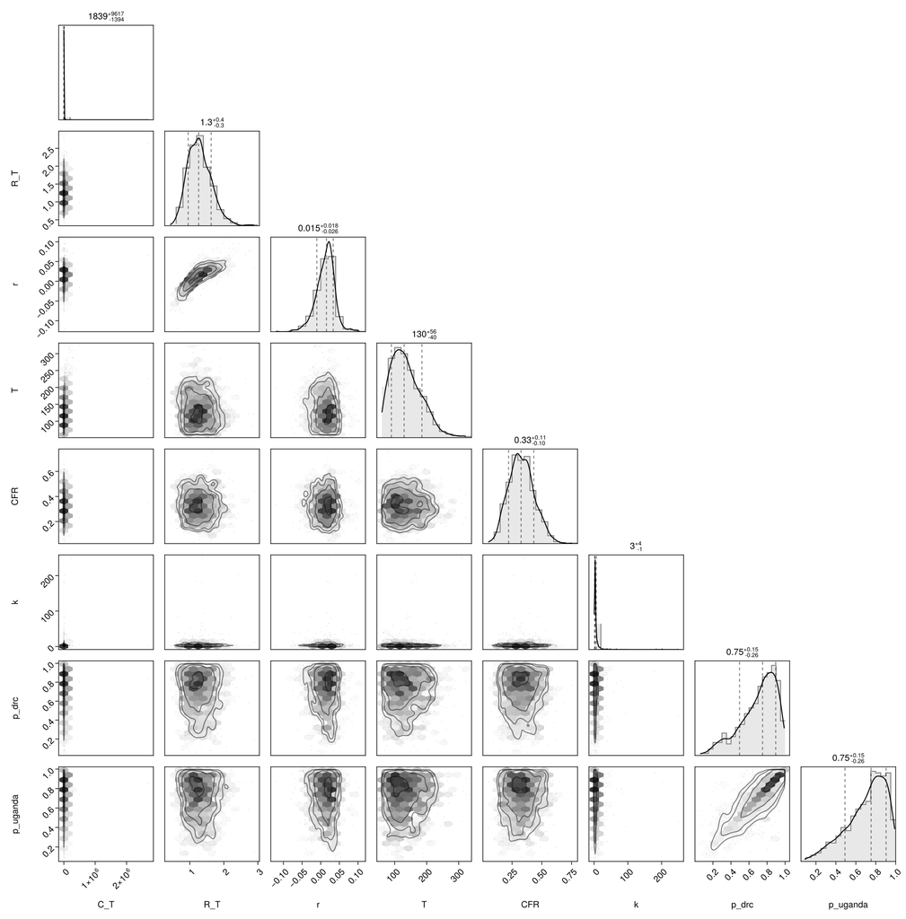

```julia
prior_pair_fig = plot_pair(prior_chn,
    [:C_T, :R_T, :r, :T, :CFR, :k,
        :p_drc, :p_uganda]);
```

#### Fitting the models

We sample with NUTS (Hoffman and Gelman, 2014) and Mooncake (Tebbutt and Ge, 2024) reverse-mode automatic differentiation, running two chains of 1000 post-warmup draws each after 1000 warmup adaptation steps, at a target acceptance probability of 0.9. Chains initialise from the prior. We fit the joint model and each single-stream model so the per-stream posteriors over the outbreak size can be compared with the joint.

**Run the joint and per-stream NUTS fits**

julia

```julia
const _BREAKPOINT = obs.n - obs.who_first_sitrep_days

# The joint and six single-stream fits are independent, so they run through
# `fit_parallel`: model-level parallelism bounded by the available threads
# (sequential on CI's two threads, several at once on a many-core machine).
# The exports-deaths composer keeps the deaths and exports submodels only
# for their CFR, onset-to-death PMF and export onsets, leaving their own
# counts missing, which leaves two redundant sampled discrete draws, so its
# model check is disabled (see `nuts_sample`).
chn_joint, chn_exports, chn_deaths, chn_cases, chn_confirmed,
chn_confirmed_deaths,
chn_exports_deaths = fit_parallel([
    () -> nuts_sample(bvd_joint(
        obs.n, obs.exported_cases, obs.total_deaths,
        obs.reported_cases, obs.exports_deaths, obs.confirmed_cases,
        obs.tests_analysed;
        confirmed_deaths = obs.confirmed_deaths,
        deaths_history = obs.deaths_history,
        reported_history = obs.reported_history,
        confirmed_history = obs.confirmed_history,
        confirmed_deaths_history = obs.confirmed_deaths_history,
        lab_history = obs.lab_history,
        tests_received_history = obs.tests_received_history,
        export_case_days = obs.export_case_days,
        export_death_days = obs.export_death_days,
        breakpoint = _BREAKPOINT,
        background_re = true,
        confirmed_positivity_link = :composition,
        genetic = genetic_seeding_model,
        tmrca_days = obs.tmrca_days)),
    () -> nuts_sample(exports_only_model(obs.n, obs.exported_cases;
        export_case_days = obs.export_case_days,
        breakpoint = _BREAKPOINT)),
    () -> nuts_sample(deaths_only_model(obs.n, obs.total_deaths;
        deaths_history = obs.deaths_history,
        breakpoint = _BREAKPOINT)),
    () -> nuts_sample(cases_only_model(obs.n, obs.reported_cases;
        reported_history = obs.reported_history,
        breakpoint = _BREAKPOINT)),
    () -> nuts_sample(confirmed_only_model(obs.n, obs.confirmed_cases;
        confirmed_history = obs.confirmed_history,
        lab_history = obs.lab_history,
        tests_received_history = obs.tests_received_history,
        breakpoint = _BREAKPOINT)),
    () -> nuts_sample(confirmed_deaths_only_model(obs.n, obs.confirmed_deaths,
        obs.total_deaths;
        deaths_history = obs.deaths_history,
        confirmed_deaths_history = obs.confirmed_deaths_history,
        breakpoint = _BREAKPOINT)),
    () -> nuts_sample(
        exports_deaths_only_model(obs.n, obs.exports_deaths;
            breakpoint = _BREAKPOINT);
        check_model = false)]);

posterior_C_joint = vec(Array(chn_joint[:C_T]));
posterior_C_exports = vec(Array(chn_exports[:C_T]));
posterior_C_deaths = vec(Array(chn_deaths[:C_T]));
posterior_C_cases = vec(Array(chn_cases[:C_T]));
posterior_C_confirmed = vec(Array(chn_confirmed[:C_T]));
posterior_C_confirmed_deaths = vec(Array(chn_confirmed_deaths[:C_T]));
posterior_C_exports_deaths = vec(Array(chn_exports_deaths[:C_T]));

# Clean display names for the summary tables and pair plots. The submodel
# prefixes (`rt_state.`, `gi_state.`, ...) are kept in the model so the
# nested submodels stay distinct; this map only relabels them for display.
display_names = Dict{Symbol, String}(
    Symbol("rt_state.sigma_rw") => "Rt step size",
    Symbol("rt_state.intervention_effect") => "intervention effect",
    Symbol("gi_state.α") => "generation interval shape",
    Symbol("gi_state.θ") => "generation interval scale",
    Symbol("inc_state.delay_mean") => "incubation period mean",
    Symbol("inc_state.delay_sd") => "incubation period SD",
    Symbol("cases_state.report_state.α") => "onset-to-report shape",
    Symbol("cases_state.report_state.θ") => "onset-to-report scale",
    Symbol("deaths_state.od_state.oa.α") => "onset-to-admission shape",
    Symbol("deaths_state.od_state.oa.θ") => "onset-to-admission scale",
    Symbol("deaths_state.od_state.ad.α") => "admission-to-death shape",
    Symbol("deaths_state.od_state.ad.θ") => "admission-to-death scale",
    Symbol("exports_state.detect_state.α") => "onset-to-detection shape",
    Symbol("exports_state.detect_state.θ") => "onset-to-detection scale",
    Symbol("confirmed_state.receipt_state.d.delay_mean") => "report-to-receipt mean",
    Symbol("confirmed_state.receipt_state.d.delay_sd") => "report-to-receipt SD",
    Symbol("exports_state.travel_state.daily_travellers") => "daily travellers");
```

[output not shown]

#### Fit diagnostics

Fit-quality diagnostics for the joint and per-stream fits: the worst R-hat, the smallest bulk effective sample size, and the number of divergent transitions.

**Fit diagnostics**

7×4 DataFrame

| Row | fit String | max_rhat Float64 | min_ess_bulk Float64 | divergences Int64 |
| --- | --- | --- | --- | --- |
| 1 | joint | 2.124 | 5.0 | 8 |
| 2 | exports (cases) | 1.007 | 1537.0 | 0 |
| 3 | exports (deaths) | 2.645 | 4.0 | 159 |
| 4 | deaths (DRC) | 1.011 | 285.0 | 12 |
| 5 | cases (DRC) | 1.006 | 1221.0 | 3 |
| 6 | confirmed (DRC) | 1.009 | 707.0 | 1 |
| 7 | confirmed deaths (DRC) | 1.005 | 1110.0 | 2 |

#### One-week-ahead forecast

We project each DRC stream seven days beyond the cut-off, letting the reproduction number keep evolving over the horizon by continuing the recent trend of its trajectory rather than holding it fixed, with no further interventions and no saturation imposed. The projection carries both parameter and observation uncertainty. We forecast the four DRC streams (suspected reported cases, suspected deaths, laboratory-confirmed cases and confirmed deaths) but not exports, since cross-border travel is unlikely to continue at its baseline rate, so the forward travel rate the export model relies on no longer holds. The figure is shown in the one-week-ahead forecast results below.

#### Forecast-versus-frozen evaluation

We assess the forecast against data observed since by freezing the data to roughly one week before the current cut-off, re-fitting, and projecting one week ahead with the same forecast machinery, then comparing that projection against the counts observed by the current cut-off. The frozen re-fit cuts the data to an earlier cut-off and re-fits the joint model, so a later result can be told apart from a later method. Each frozen re-fit uses the full headline settings (1000 draws across two chains). The same frozen re-fit is reused to compare against McCabe et al. at the cut-offs they used, and to trace how the estimate moved as the situation reports accrued, re-fitting the renewal model frozen at each release date. The helper below performs one frozen joint re-fit and is reused by the forecast validation, estimate-evolution and matched-in-time results.

**Frozen-fit helper (reused by the forecast validation, evolution and matched-in-time sections)**

julia

```julia
# A joint fit at the full headline settings (1000 draws × 2 chains) to the
# data frozen at `cutoff_date`. The frozen named tuple has the same shape as
# the full `obs`, so the model call mirrors the headline joint fit.
function fit_frozen_joint(cutoff_date; samples = 1000, chains = 2)
    o = freeze_observations(cutoff_date)
    bp = o.n - o.who_first_sitrep_days
    chn = nuts_sample(
        bvd_joint(
            o.n, o.exported_cases, o.total_deaths,
            o.reported_cases, o.exports_deaths, o.confirmed_cases,
            o.tests_analysed;
            confirmed_deaths = o.confirmed_deaths,
            deaths_history = o.deaths_history,
            reported_history = o.reported_history,
            confirmed_history = o.confirmed_history,
            confirmed_deaths_history = o.confirmed_deaths_history,
            lab_history = o.lab_history,
            tests_received_history = o.tests_received_history,
            export_case_days = o.export_case_days,
            export_death_days = o.export_death_days,
            breakpoint = bp,
            background_re = true,
            confirmed_positivity_link = :composition,
            genetic = genetic_seeding_model,
            tmrca_days = o.tmrca_days);
        samples = samples, chains = chains)
    return (; cutoff = o.cutoff, o, chn)
end
```

```
fit_frozen_joint (generic function with 1 method)
```

## Results

### Summary

The numbers below are our estimate of the underlying infections to date, reported and unreported, from the joint posterior. Each is given as equal-tailed 30%, 60% and 90% credible intervals.

**Compute the headline ranges**

julia

```julia
summary_ranges = let
    med(x) = quantile(x, 0.5)
    iqr(x) = quantile(x, 0.75) - quantile(x, 0.25)
    # Posterior-minus-prior shift in units of the parameter's prior IQR,
    # reusing the prior draws so nothing is respecified here.
    shift(post, prior) = round((med(post) - med(prior)) / iqr(prior);
        digits = 2)

    C = posterior_C_joint
    Td = vec(Array(chn_joint[:T]))
    r0d = vec(Array(chn_joint[:r0]))
    rd = vec(Array(chn_joint[:r]))
    dt0 = log(2) ./ r0d
    dt = vec(Array(chn_joint[:doubling_time]))
    R0d = vec(Array(chn_joint[:R0]))
    RTd = vec(Array(chn_joint[:R_T]))
    cfrd = vec(Array(chn_joint[:CFR]))
    sC = posterior_summary(C)
    sT = posterior_summary(Td)
    sr0 = posterior_summary(r0d)
    sr = posterior_summary(rd)
    sdt0 = posterior_summary(dt0)
    sdt = posterior_summary(dt)
    sR0 = posterior_summary(R0d)
    sRT = posterior_summary(RTd)
    scfr = posterior_summary(cfrd)

    ints_i(s) = string(
        "30% ", round(Int, s.lo30), "–", round(Int, s.hi30),
        ", 60% ", round(Int, s.lo60), "–", round(Int, s.hi60),
        ", 90% ", round(Int, s.lo90), "–", round(Int, s.hi90))
    ints_f(s,
        d) = string(
        "30% ", round(s.lo30; digits = d), "–", round(s.hi30; digits = d),
        ", 60% ", round(s.lo60; digits = d), "–", round(s.hi60; digits = d),
        ", 90% ", round(s.lo90; digits = d), "–", round(s.hi90; digits = d))
    start_from(t) = obs.cutoff - Day(round(Int, t))
    ints_d(s) = string(
        "30% ", start_from(s.hi30), "–", start_from(s.lo30),
        ", 60% ", start_from(s.hi60), "–", start_from(s.lo60),
        ", 90% ", start_from(s.hi90), "–", start_from(s.lo90))
    f_lo = round(sC.lo90 / obs.confirmed_cases; digits = 1)
    f_hi = round(sC.hi90 / obs.confirmed_cases; digits = 1)
    ec = posterior_summary(vec(Array(chn_joint[:expected_confirmed_T])))

    # How far the data has moved each estimate from its prior, in prior
    # interquartile ranges, reusing the prior draws.
    moves = [
        "cumulative infection count" => shift(C, vec(Array(prior_chn[:C_T]))),
        "outbreak age" => shift(Td, vec(Array(prior_chn[:T]))),
        "doubling time" => shift(dt, vec(Array(prior_chn[:doubling_time])))]
    biggest = argmax(p -> abs(p.second), moves)

    Markdown.parse("""
    - **Cumulative infections:** the outbreak is estimated to have caused
      $(ints_i(sC)) infections to date, reported and unreported.
    - Against the $(obs.confirmed_cases) laboratory-confirmed cases by the
      cut-off that is roughly $(f_lo)–$(f_hi)× as many infections, so
      confirmed cases are estimated to capture only a small share of the
      outbreak.
    - **Confirmed-case fit:** the model expects $(ints_i(ec)) confirmed
      cases by the cut-off, against $(obs.confirmed_cases) observed.
    - **Outbreak start and age:** the outbreak is estimated to have begun on
      a start date of $(ints_d(sT)), an elapsed age to the cut-off of
      $(ints_i(sT)) days.
    - **Growth rate and doubling time:** the initial growth rate is
      estimated to have been $(ints_f(sr0, 3)) per day, an initial doubling
      time of $(ints_f(sdt0, 1)) days.
      The latest growth rate is estimated to be $(ints_f(sr, 3)) per day, a
      latest doubling time of $(ints_f(sdt, 1)) days.
    - **Reproduction number:** the initial reproduction number is estimated
      to have been $(ints_f(sR0, 2)) and the latest to be $(ints_f(sRT, 2)).
    - **Case-fatality ratio:** the case-fatality ratio is estimated to be
      $(ints_f(scfr, 2)).
    - **Shift from priors:** how far the data has moved each estimate from
      its prior, in prior interquartile ranges, where a value of one means
      the posterior median sits one prior interquartile range from the prior
      median, zero means unchanged, and the sign gives the direction.
      The fit moves the cumulative infection count by $(moves[1].second),
      the outbreak age by $(moves[2].second) and the doubling time by
      $(moves[3].second); the largest move is in the $(biggest.first).
    """)
end;
```

- **Cumulative infections:** the outbreak is estimated to have caused 30% 3498–5018, 60% 2958–6822, 90% 2345–12421 infections to date, reported and unreported.
- Against the 550 laboratory-confirmed cases by the cut-off that is roughly 4.3–22.6× as many infections, so confirmed cases are estimated to capture only a small share of the outbreak.
- **Confirmed-case fit:** the model expects 30% 807–960, 60% 734–1081, 90% 634–1352 confirmed cases by the cut-off, against 550 observed.
- **Outbreak start and age:** the outbreak is estimated to have begun on a start date of 30% 2026-02-06–2026-02-18, 60% 2026-01-29–2026-02-26, 90% 2026-01-13–2026-03-09, an elapsed age to the cut-off of 30% 109–121, 60% 101–129, 90% 90–145 days.
- **Growth rate and doubling time:** the initial growth rate is estimated to have been 30% 0.037–0.042, 60% 0.034–0.045, 90% 0.03–0.05 per day, an initial doubling time of 30% 16.6–18.7, 60% 15.5–20.1, 90% 13.8–22.8 days. The latest growth rate is estimated to be 30% 0.038–0.062, 60% 0.029–0.083, 90% 0.01–0.13 per day, a latest doubling time of 30% 10.7–17.8, 60% 7.9–22.5, 90% 4.5–43.6 days.
- **Reproduction number:** the initial reproduction number is estimated to have been 30% 1.47–1.73, 60% 1.36–1.92, 90% 1.21–2.28 and the latest to be 30% 1.64–1.99, 60% 1.46–2.33, 90% 1.25–3.18.
- **Case-fatality ratio:** the case-fatality ratio is estimated to be 30% 0.33–0.4, 60% 0.29–0.44, 90% 0.23–0.52.
- **Shift from priors:** how far the data has moved each estimate from its prior, in prior interquartile ranges, where a value of one means the posterior median sits one prior interquartile range from the prior median, zero means unchanged, and the sign gives the direction. The fit moves the cumulative infection count by 0.39, the outbreak age by -0.2 and the doubling time by -0.17; the largest move is in the cumulative infection count.

### Joint model estimates

This section reports the joint posterior over the cumulative infection count to date, fitting every data stream together.

**Cumulative infection count summary table**

julia

```julia
cumulative_cases_summary = summary_table(
    chn_joint, [:C_T]; digits = 0);
```

1×7 DataFrame

| Row | Quantity String | Lower 90% Float64 | Lower 60% Float64 | Lower 30% Float64 | Upper 30% Float64 | Upper 60% Float64 | Upper 90% Float64 |
| --- | --- | --- | --- | --- | --- | --- | --- |
| 1 | C_T | 2345.0 | 2958.0 | 3498.0 | 5018.0 | 6822.0 | 12421.0 |

The figure below shows three modelled cumulative quantities over time, one per row, all latent. The top row is infections, the middle row symptom onsets and the bottom row deaths. The left column is the modelled cumulative trajectory with its 50% and 90% intervals; the right column is the posterior density of the current cut-off cumulative. The infection density on the top right is the headline outbreak size, a count of infections rather than reported cases. No observed counts are overlaid, since each quantity sits upstream of the ascertainment, confirmation and reporting that produce the observations.

**Cumulative infections, onsets and deaths figure**

julia

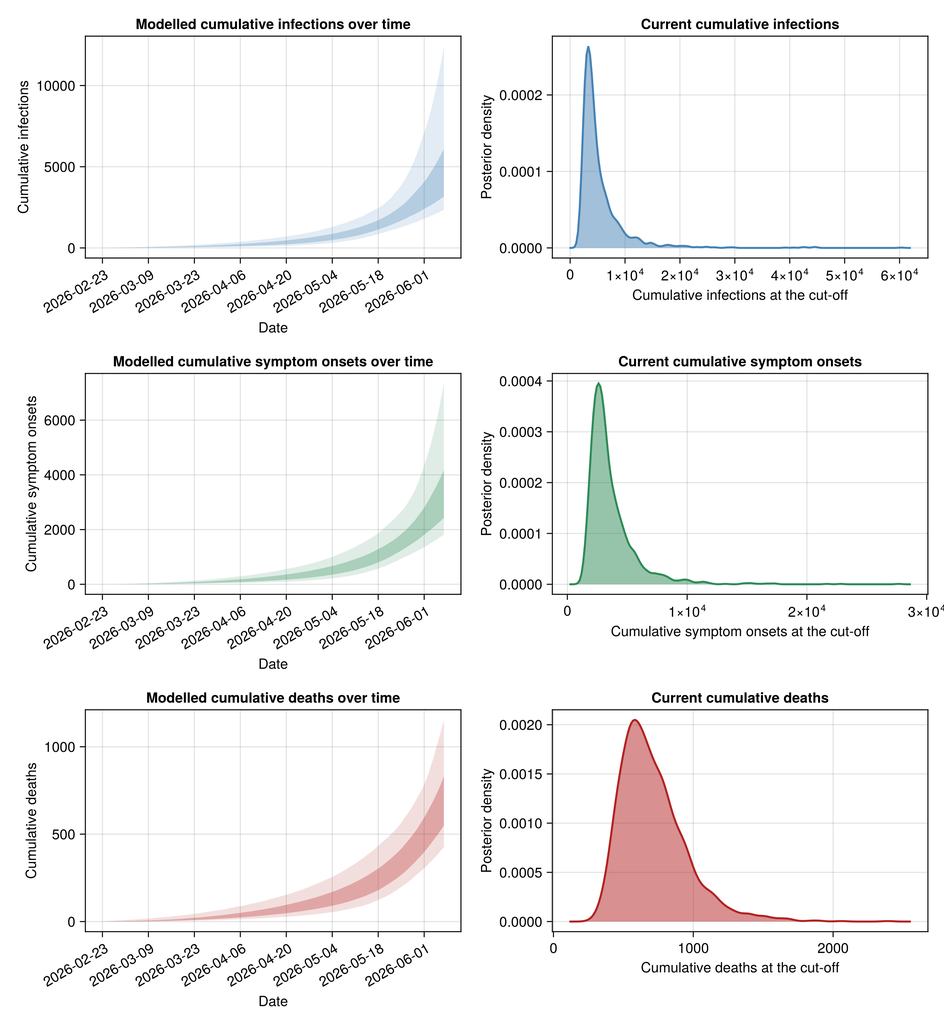

```julia
cumulative_traj_fig = plot_cumulative_trajectories(chn_joint;
    n = obs.n, seeding = obs.seeding);
```

**Outbreak start date and seeding-time posterior**

julia

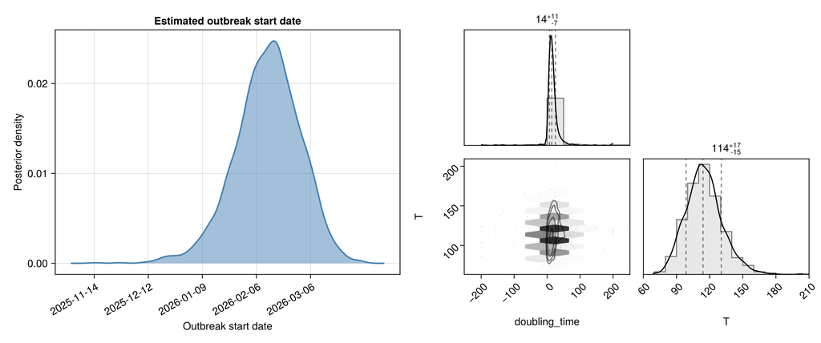

```julia
start_date_fig = plot_start_date_pair(chn_joint;
    as_of_date = string(obs.cutoff));
```

**Infection-parameter summary table**

julia

```julia
infection_summary = summary_table(chn_joint,
    [:r, :doubling_time, :T, :R_T, :CFR, :C_T]; digits = 2);
```

6×7 DataFrame

| Row | Quantity String | Lower 90% Float64 | Lower 60% Float64 | Lower 30% Float64 | Upper 30% Float64 | Upper 60% Float64 | Upper 90% Float64 |
| --- | --- | --- | --- | --- | --- | --- | --- |
| 1 | r | 0.01 | 0.03 | 0.04 | 0.06 | 0.08 | 0.13 |
| 2 | doubling_time | 4.48 | 7.91 | 10.69 | 17.8 | 22.51 | 43.56 |
| 3 | T | 89.69 | 101.4 | 108.57 | 120.9 | 128.56 | 144.9 |
| 4 | R_T | 1.25 | 1.46 | 1.64 | 1.99 | 2.33 | 3.18 |
| 5 | CFR | 0.23 | 0.29 | 0.33 | 0.4 | 0.44 | 0.52 |
| 6 | C_T | 2345.02 | 2958.27 | 3497.78 | 5017.93 | 6821.9 | 12421.1 |

**Infection-parameter pair plot (prior overlaid)**

julia

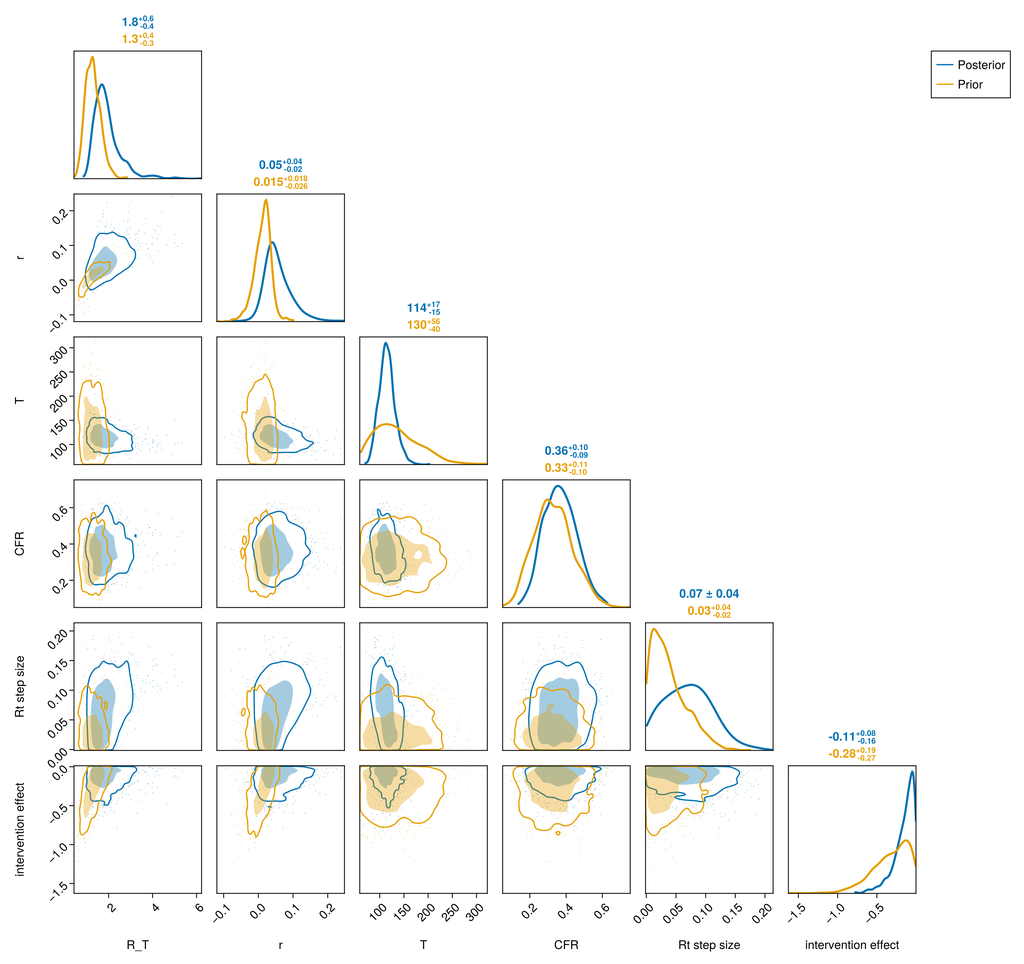

```julia
infection_pair_fig = plot_pair(chn_joint,
    [:R_T, :r, :T, :CFR,
        Symbol("rt_state.sigma_rw"), Symbol("rt_state.intervention_effect")];
    prior = prior_chn, labels = display_names);
```

**Infection-delay summary table**

julia

```julia
infection_delay_summary = summary_table(chn_joint,
    [Symbol("gi_state.α"), Symbol("gi_state.θ"),
        Symbol("inc_state.delay_mean"), Symbol("inc_state.delay_sd")];
    digits = 2, labels = display_names);
```

4×7 DataFrame

| Row | Quantity String | Lower 90% Float64 | Lower 60% Float64 | Lower 30% Float64 | Upper 30% Float64 | Upper 60% Float64 | Upper 90% Float64 |
| --- | --- | --- | --- | --- | --- | --- | --- |
| 1 | generation interval shape | 1.31 | 1.91 | 2.27 | 2.87 | 3.21 | 3.83 |
| 2 | generation interval scale | 2.85 | 4.09 | 4.81 | 6.08 | 6.78 | 8.08 |
| 3 | incubation period mean | 5.38 | 5.81 | 6.03 | 6.45 | 6.72 | 7.15 |
| 4 | incubation period SD | 2.19 | 2.81 | 3.18 | 3.86 | 4.26 | 4.87 |

**Infection-delay pair plot (prior overlaid)**

julia

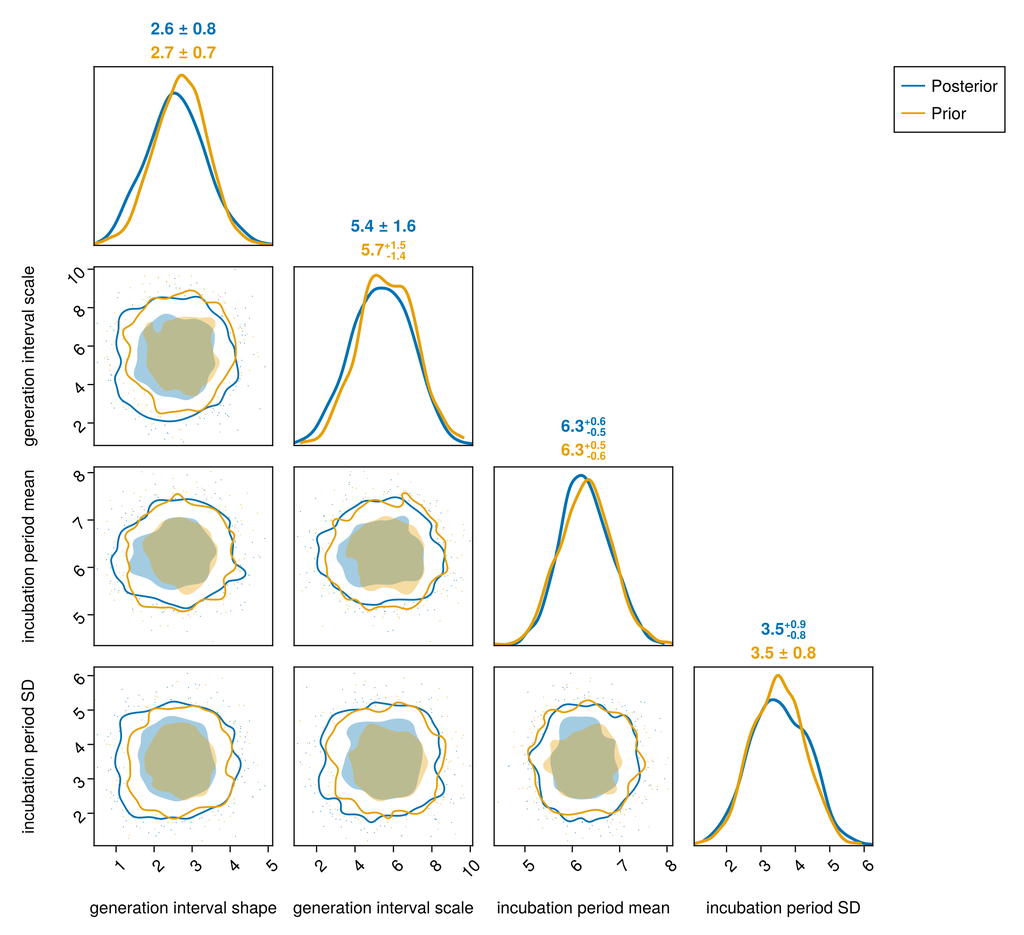

```julia
infection_delay_pair_fig = plot_pair(chn_joint,
    [Symbol("gi_state.α"), Symbol("gi_state.θ"),
        Symbol("inc_state.delay_mean"), Symbol("inc_state.delay_sd")];
    prior = prior_chn, labels = display_names);
```

### Reproduction number over time

The daily reproduction number over the period we estimate it for, the established outbreak from the genetic bound to the cut-off. The 30%, 60% and 90% credible ribbons are shown with about a hundred sampled trajectories, and the no-growth threshold at one as a grey dashed line. The first situation report on 18 May 2026 marks the start of the response scale-up (red dashed) and the end of the three-week scale-up is the red dotted line; the data cut-off is grey dashed.

**Reproduction-number trajectory**

julia

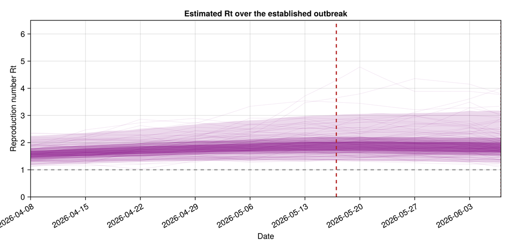

```julia
rt_fig = plot_rt(chn_joint;
    n = obs.n, breakpoint = _BREAKPOINT,
    rt_start = clamp(
        obs.n - round(Int, obs.tmrca_days) + RENEWAL_START_LEAD, 1, obs.n),
    as_of_date = string(obs.cutoff), seeding = obs.seeding,
    ramp = 21.0);
```

The table reports the posterior of the response effect on the reproduction number as a multiplier, where a value below one is the factor by which the response lowers the reproduction number once the scale-up completes.

**Intervention-effect summary table**

julia

```julia
intervention_effect = vec(Array(
    chn_joint[Symbol("rt_state.intervention_effect")]));
intervention_table = streams_table(
    "Rt multiplier exp(effect)" => exp.(intervention_effect);
    digits = 2);
```

1×7 DataFrame

| Row | Stream String | Lower 90% Float64 | Lower 60% Float64 | Lower 30% Float64 | Upper 30% Float64 | Upper 60% Float64 | Upper 90% Float64 |
| --- | --- | --- | --- | --- | --- | --- | --- |
| 1 | Rt multiplier exp(effect) | 0.66 | 0.78 | 0.85 | 0.93 | 0.96 | 0.99 |

### Observation delays

The delays from symptom onset to each observed event: onset to a suspected case being reported, onset to death, onset to detection abroad (the export model uses the same onset-to-admission delay as the report), and the report-to-laboratory receipt delay. The onset-to-report and onset-to-detection delays are the same line-list onset-to-admission delay, sampled on its natural Gamma shape and scale, and onset-to-death is the convolution of two atomic Gamma delays, onset to admission and admission to death, each with its own shape and scale. The report-to-receipt delay is sampled by its mean and standard deviation. The table reports their posteriors; the pair plot beside it shows their joint posterior with the prior overlaid, so the data's contribution to each marginal is visible.

**Observation-delay summary table**

julia

```julia
obs_delay_summary = summary_table(chn_joint,
    [Symbol("cases_state.report_state.α"),
        Symbol("cases_state.report_state.θ"),
        Symbol("deaths_state.od_state.oa.α"),
        Symbol("deaths_state.od_state.oa.θ"),
        Symbol("deaths_state.od_state.ad.α"),
        Symbol("deaths_state.od_state.ad.θ"),
        Symbol("exports_state.detect_state.α"),
        Symbol("exports_state.detect_state.θ"),
        Symbol("confirmed_state.receipt_state.d.delay_mean"),
        Symbol("confirmed_state.receipt_state.d.delay_sd")];
    digits = 2, labels = display_names);
```

10×7 DataFrame

| Row | Quantity String | Lower 90% Float64 | Lower 60% Float64 | Lower 30% Float64 | Upper 30% Float64 | Upper 60% Float64 | Upper 90% Float64 |
| --- | --- | --- | --- | --- | --- | --- | --- |
| 1 | onset-to-report shape | 0.73 | 0.96 | 1.08 | 1.29 | 1.43 | 1.64 |
| 2 | onset-to-report scale | 1.93 | 2.83 | 3.3 | 4.21 | 4.69 | 5.53 |
| 3 | onset-to-admission shape | 0.7 | 0.92 | 1.05 | 1.28 | 1.41 | 1.63 |
| 4 | onset-to-admission scale | 1.54 | 2.46 | 3.1 | 4.05 | 4.64 | 5.64 |
| 5 | admission-to-death shape | 1.05 | 1.55 | 1.83 | 2.29 | 2.58 | 3.05 |
| 6 | admission-to-death scale | 1.6 | 2.64 | 3.19 | 4.28 | 4.92 | 5.97 |
| 7 | onset-to-detection shape | 0.69 | 0.92 | 1.05 | 1.29 | 1.42 | 1.65 |
| 8 | onset-to-detection scale | 1.56 | 2.59 | 3.19 | 4.14 | 4.69 | 5.69 |
| 9 | report-to-receipt mean | 3.18 | 3.36 | 3.48 | 7.81 | 7.98 | 8.19 |
| 10 | report-to-receipt SD | 1.0 | 1.01 | 1.01 | 1.03 | 1.04 | 1.08 |

**Observation-delay pair plot (prior overlaid)**

julia

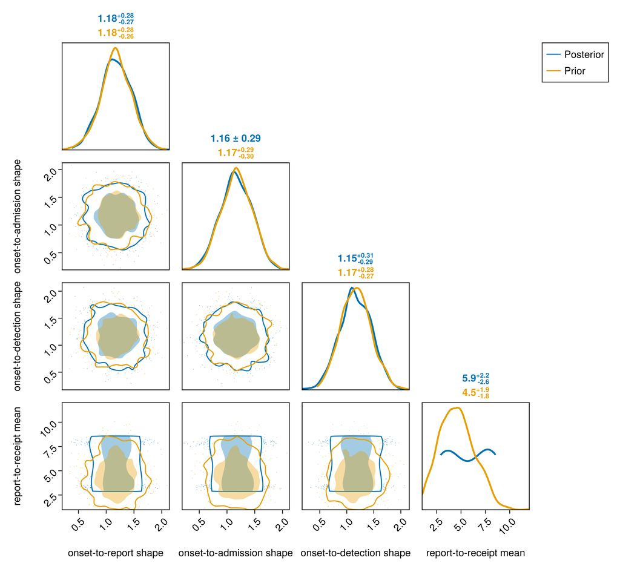

```julia
obs_delay_pair_fig = plot_pair(chn_joint,
    [Symbol("cases_state.report_state.α"),
        Symbol("deaths_state.od_state.oa.α"),
        Symbol("exports_state.detect_state.α"),
        Symbol("confirmed_state.receipt_state.d.delay_mean")];
    prior = prior_chn, labels = display_names);
```

### Surveillance parameters

The surveillance-data parameters: the reporting fractions for the DRC and Uganda, the surveillance dispersion, and the laboratory pipeline (the testing fraction and receipt delay, the per-suspected and per-test positivity, the non-BVD background rate, and the death-confirmation probability). The table reports their credible intervals; the pair plot beside it shows their joint posterior with the prior overlaid.

**Surveillance-parameter summary table**

julia

```julia
surveillance_summary = summary_table(chn_joint,
    [:p_drc, :p_uganda, :k, :tau_test, :lambda_bg,
        :suspected_positivity, :test_positivity, :expected_confirmed_T,
        :expected_received_T, :m_death, :death_composition,
        :death_confirmation, :expected_confirmed_deaths_T];
    digits = 3);
```

13×7 DataFrame

| Row | Quantity String | Lower 90% Float64 | Lower 60% Float64 | Lower 30% Float64 | Upper 30% Float64 | Upper 60% Float64 | Upper 90% Float64 |
| --- | --- | --- | --- | --- | --- | --- | --- |
| 1 | p_drc | 0.389 | 0.542 | 0.639 | 0.781 | 0.851 | 0.934 |
| 2 | p_uganda | 0.35 | 0.519 | 0.627 | 0.781 | 0.845 | 0.935 |
| 3 | k | 0.792 | 0.92 | 1.0 | 1.143 | 1.257 | 1.438 |
| 4 | tau_test | 0.454 | 0.555 | 0.618 | 0.732 | 0.801 | 0.891 |
| 5 | lambda_bg | 0.831 | 1.226 | 1.497 | 2.013 | 2.349 | 2.967 |
| 6 | suspected_positivity | 0.034 | 0.048 | 0.06 | 0.446 | 0.494 | 0.543 |
| 7 | test_positivity | 0.029 | 0.037 | 0.044 | 0.53 | 0.584 | 0.636 |
| 8 | expected_confirmed_T | 633.725 | 733.697 | 806.919 | 959.52 | 1080.73 | 1352.34 |
| 9 | expected_received_T | 1516.71 | 1883.02 | 2246.06 | 21265.8 | 27363.7 | 37691.7 |
| 10 | m_death | 0.3 | 0.526 | 0.869 | 3.041 | 5.056 | 9.201 |
| 11 | death_composition | 0.034 | 0.048 | 0.06 | 0.446 | 0.494 | 0.543 |
| 12 | death_confirmation | 0.108 | 0.159 | 0.211 | 0.313 | 0.405 | 0.583 |
| 13 | expected_confirmed_deaths_T | 96.776 | 125.963 | 147.297 | 195.655 | 234.507 | 319.503 |

**Surveillance-parameter pair plot (prior overlaid)**

julia

```julia
surveillance_pair_fig = plot_pair(chn_joint,
    [:p_drc, :p_uganda, :k, :tau_test, :lambda_bg, :test_positivity,
        :death_confirmation];
    prior = prior_chn);
```

[output not shown]

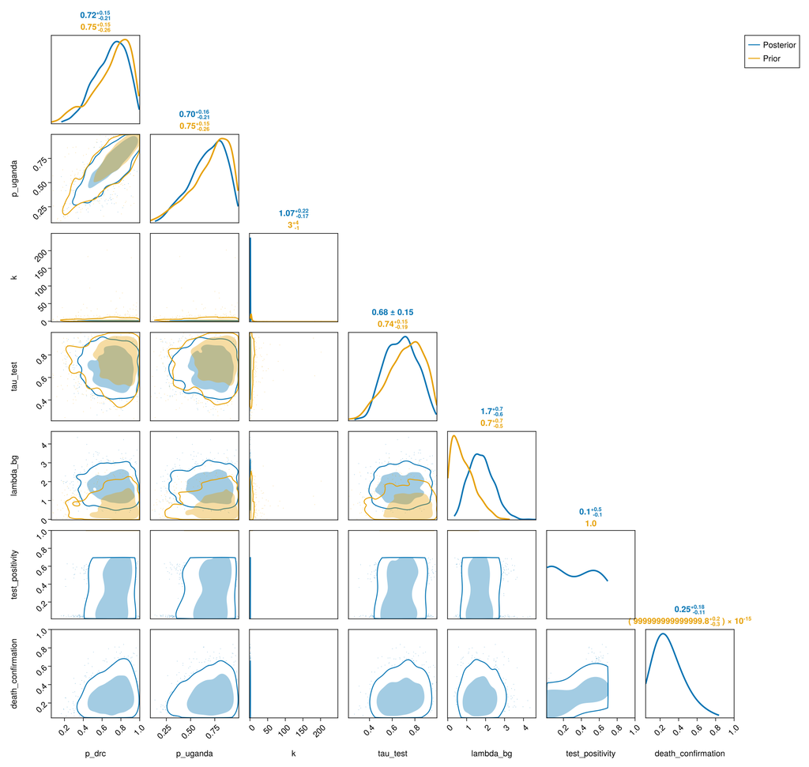

### Posterior predictive checks

A posterior predictive check draws replicated observations from the fitted joint model and compares them to the observed counts. The checks read in three groups, following the generative order of the model. The first is the infection process, the latent infections, symptom onsets and deaths that drive every stream; these are not observed directly, so they carry no genuine replicate and are shown as the estimated cumulative trajectories in the joint model estimates figure rather than checked against data here. The second is the surveillance data, the five dated DRC streams that are real per-vintage observations: suspected cases, confirmed cases, suspected deaths, confirmed deaths and specimens received. The third is the exports, the cross-border imported cases and deaths detected in Uganda.

**Joint posterior predictive plot**

julia

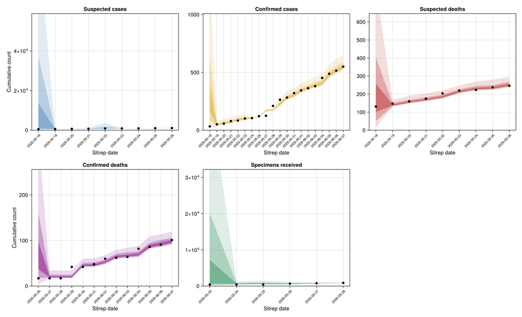

```julia
# Drop the increment counts but keep each stream's vintage day grid, so
# `predict` resamples the per-vintage increments rather than holding them
# at the observed values. The confirmed-case windows and the per-window
# positivity random effect are defined by the confirmed and laboratory
# histories, so those are passed with their counts intact (only the
# cut-off scalars are set to `missing`) to keep the generator's latent
# dimensions identical to the fitted chain.
_days_only(h) = (; days = h.days, counts = Int[]);

pp_joint = predict(
    bvd_joint(
        obs.n, missing, missing, missing, missing, missing, missing;
        confirmed_deaths = missing,
        deaths_history = _days_only(obs.deaths_history),
        reported_history = _days_only(obs.reported_history),
        confirmed_history = obs.confirmed_history,
        confirmed_deaths_history = _days_only(obs.confirmed_deaths_history),
        lab_history = obs.lab_history,
        tests_received_history = _days_only(obs.tests_received_history),
        export_case_days = obs.export_case_days,
        export_death_days = obs.export_death_days,
        breakpoint = _BREAKPOINT,
        background_re = true,
        confirmed_positivity_link = :composition,
        genetic = genetic_seeding_model,
        tmrca_days = obs.tmrca_days),
    chn_joint);

# `predict` stores each stream's per-vintage increments as one
# vector-valued variable (`<stream>_increments.increments`); the slice is
# an iter×chain matrix of per-draw increment vectors, exactly the
# `replicates` shape `plot_vintage_conditional_ppc` grounds on each
# vintage's observed previous cumulative for the one-step-ahead
# predictive. Find it by its prefix among the predict keys.
function _vintage_replicates(pp, prefix)
    key = first(k for k in keys(pp)
    if occursin("$prefix.increments", string(k)))
    return collect(pp[key])
end;

# Grid day-index → INSP situation-report date label.
_vintage_dates(days) = string.(obs.seeding .+ Day.(days .- 1));

reported_panel = (;
    title = "Suspected cases",
    dates = _vintage_dates(obs.reported_history.days),
    replicates = _vintage_replicates(
        pp_joint, "cases_state.reported_increments"),
    observed = obs.reported_history.counts, colour = :steelblue);
deaths_panel = (;
    title = "Suspected deaths",
    dates = _vintage_dates(obs.deaths_history.days),
    replicates = _vintage_replicates(
        pp_joint, "deaths_state.death_increments"),
    observed = obs.deaths_history.counts, colour = :firebrick);
# Specimens received is also a per-vintage time series (the receipt-delay
# and tested-fraction throughput), so it gets the same cumulative
# conditional check as the suspected streams.
tests_received_panel = (;
    title = "Specimens received",
    dates = _vintage_dates(obs.tests_received_history.days),
    replicates = _vintage_replicates(
        pp_joint, "confirmed_state.received_increments"),
    observed = obs.tests_received_history.counts, colour = :seagreen);

# Confirmed cases are scored over two groups of laboratory windows: the
# early confirmed vintages (no per-vintage analysed denominator, scored
# as counts against the modelled laboratory volume) and the observed
# windows (a Binomial of the observed analysed denominator). Both groups
# produce per-window replicate increments in `predict`, so concatenating
# them oldest-first gives the per-vintage cumulative confirmed-case
# trajectory, grounded on the observed cumulative confirmed at each window
# end-day. The 24-25 May analysis stall merges into 26 May, so the window
# grid is slightly coarser than the raw confirmed history.
_conf_windows = BVDOutbreakSize.confirmed_positivity_windows(
    obs.confirmed_history, obs.lab_history);
# Oldest-first: early (no denominator) → observed (analysed Binomial) →
# late (post-28 May, no denominator, modelled volume).
_conf_window_days = vcat(_conf_windows.early_days, _conf_windows.obs_days,
    _conf_windows.late_days);
function _confirmed_at(day)
    i = searchsortedlast(obs.confirmed_history.days, day)
    return i == 0 ? 0 : Int(obs.confirmed_history.counts[i])
end;
_conf_early = _vintage_replicates(
    pp_joint, "confirmed_state.early_increments");
_conf_obs = collect(first(pp_joint[k]
for k in keys(pp_joint)
if occursin("confirmed_state.confirmed_positives.positives", string(k))));
_conf_late = _vintage_replicates(
    pp_joint, "confirmed_state.late_increments");
confirmed_panel = (;
    title = "Confirmed cases",
    dates = _vintage_dates(_conf_window_days),
    replicates = [vcat(collect(e), collect(p), collect(l))
                  for (e, p, l) in zip(vec(_conf_early), vec(_conf_obs), vec(_conf_late))],
    observed = [_confirmed_at(d) for d in _conf_window_days],
    colour = :goldenrod);

# Confirmed deaths are a per-vintage stream, scored as increments of the
# modelled confirmed-death trajectory up to the cut-off, so they get the
# same cumulative conditional check.
confirmed_deaths_panel = (;
    title = "Confirmed deaths",
    dates = _vintage_dates(obs.confirmed_deaths_history.days),
    replicates = _vintage_replicates(
        pp_joint, "confirmed_deaths_state.cdeath_increments"),
    observed = obs.confirmed_deaths_history.counts, colour = :purple);

# Each panel runs to its own last vintage: the suspected case and death
# streams freeze at 26 May (their last stable vintage) while the
# laboratory-confirmed streams keep reporting to the cut-off, so the
# confirmed panels show the full series the model is fitting, not just the
# window the suspected streams cover.
joint_vintage_ppc_fig = plot_vintage_conditional_ppc(
    [reported_panel, confirmed_panel, deaths_panel,
    confirmed_deaths_panel, tests_received_panel]);
```

The exports group is checked next. The Uganda export and export-death streams are dated per-day series, each import or death scored as a Poisson at its detection day. The scalar posterior predictive sums each replicate's per-day count vector across the dated days, giving the cumulative export and death total to compare with the observed count.

**Scalar posterior predictive plot**

julia

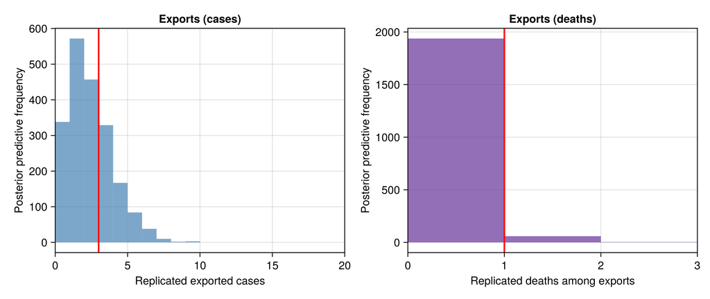

```julia
# The dated counts are nested under their submodel prefix as a single
# per-day count vector `<prefix>.counts`; match the full prefixed varname so
# the deterministic `expected_*_T` quantities are not picked up by a loose
# substring, then sum each replicate's per-day vector into the total.
function _dated_total(pp, name)
    key = first(k for k in keys(pp) if occursin("$name.counts", string(k)))
    return [sum(v) for v in vec(Array(pp[key]))]
end;

pp_exports = _dated_total(pp_joint, "exports_state.export_obs");
pp_exports_deaths = _dated_total(
    pp_joint, "exports_deaths_state.death_obs");

joint_ppc_fig = plot_posterior_predictive(
    pp_exports, nothing,
    obs.exported_cases, nothing;
    pp_exports_deaths = pp_exports_deaths,
    obs_exports_deaths = obs.exports_deaths);
```

### Counterfactual: lower bound under no further transmission

The committed future deaths if transmission stopped at the report date, defined in the methods counterfactual.

**Project no-onward deaths and summarise**

julia

```julia
no_onward = predict_no_onward_deaths(
    chn_joint; obs_deaths = obs.total_deaths);

no_onward_table = streams_table(
    "no-onward total" => no_onward.total_projected;
    digits = 0);
```

1×7 DataFrame

| Row | Stream String | Lower 90% Float64 | Lower 60% Float64 | Lower 30% Float64 | Upper 30% Float64 | Upper 60% Float64 | Upper 90% Float64 |
| --- | --- | --- | --- | --- | --- | --- | --- |
| 1 | no-onward total | 538.0 | 715.0 | 858.0 | 1291.0 | 1848.0 | 3789.0 |

**No-onward projected-deaths plot**

julia

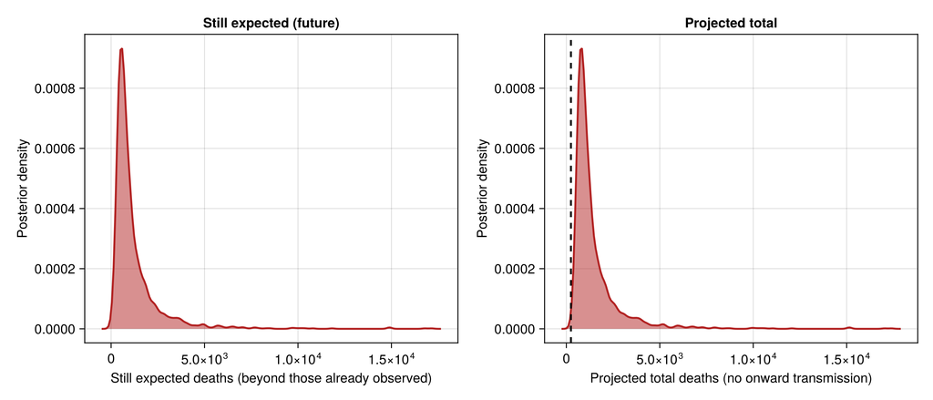

```julia
no_onward_fig = plot_no_onward_deaths(
    no_onward; obs_deaths = obs.total_deaths);
```

### One-week-ahead forecast results

**Generate the one-week-ahead forecast**

julia

```julia
forecast = forecast_reported(chn_joint;
    horizon = 7,
    obs_cases = obs.reported_cases,
    obs_deaths = obs.total_deaths,
    obs_confirmed = obs.confirmed_cases,
    obs_confirmed_deaths = obs.confirmed_deaths);
forecast_summary = forecast_table(forecast);
```

8×8 DataFrame

| Row | Stream String | Quantity String | Lower 90% Float64 | Lower 60% Float64 | Lower 30% Float64 | Upper 30% Float64 | Upper 60% Float64 | Upper 90% Float64 |
| --- | --- | --- | --- | --- | --- | --- | --- | --- |
| 1 | DRC reported cases | cumulative by T+7 | 470.0 | 2102.0 | 4467.0 | 22414.0 | 62247.0 | 167764.0 |
| 2 | DRC reported cases | new this week | 0.0 | 1025.0 | 3390.0 | 21337.0 | 61170.0 | 166687.0 |
| 3 | DRC deaths | cumulative by T+7 | 59.0 | 254.0 | 480.0 | 1112.0 | 1775.0 | 3835.0 |
| 4 | DRC deaths | new this week | 0.0 | 8.0 | 234.0 | 866.0 | 1529.0 | 3589.0 |
| 5 | DRC confirmed cases | cumulative by T+7 | 74.0 | 310.0 | 584.0 | 1452.0 | 2308.0 | 4480.0 |
| 6 | DRC confirmed cases | new this week | 0.0 | 0.0 | 34.0 | 902.0 | 1758.0 | 3930.0 |
| 7 | DRC confirmed deaths | cumulative by T+7 | 9.0 | 47.0 | 90.0 | 228.0 | 349.0 | 671.0 |
| 8 | DRC confirmed deaths | new this week | 0.0 | 0.0 | 0.0 | 127.0 | 248.0 | 570.0 |

The coming week at a glance, split into the latent quantities and the observations. The latent figure shows the new infections, symptom onsets and deaths over the horizon, with the reproduction number left to keep evolving across it.

**One-week-ahead latent forecast plot**

julia

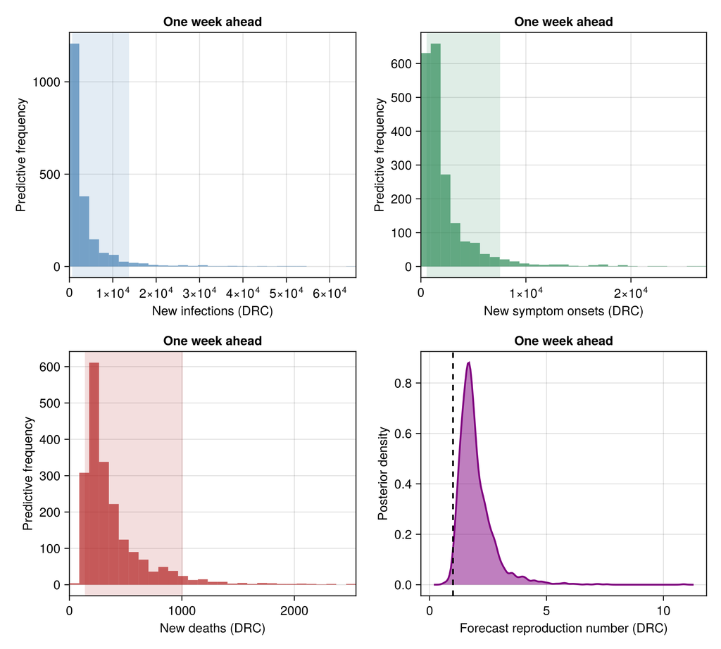

```julia
forecast_latent_fig = plot_forecast_latent(forecast);
```

The observation figure shows the new reported cases, confirmed cases and confirmed deaths over the horizon.

**One-week-ahead observed forecast plot**

julia

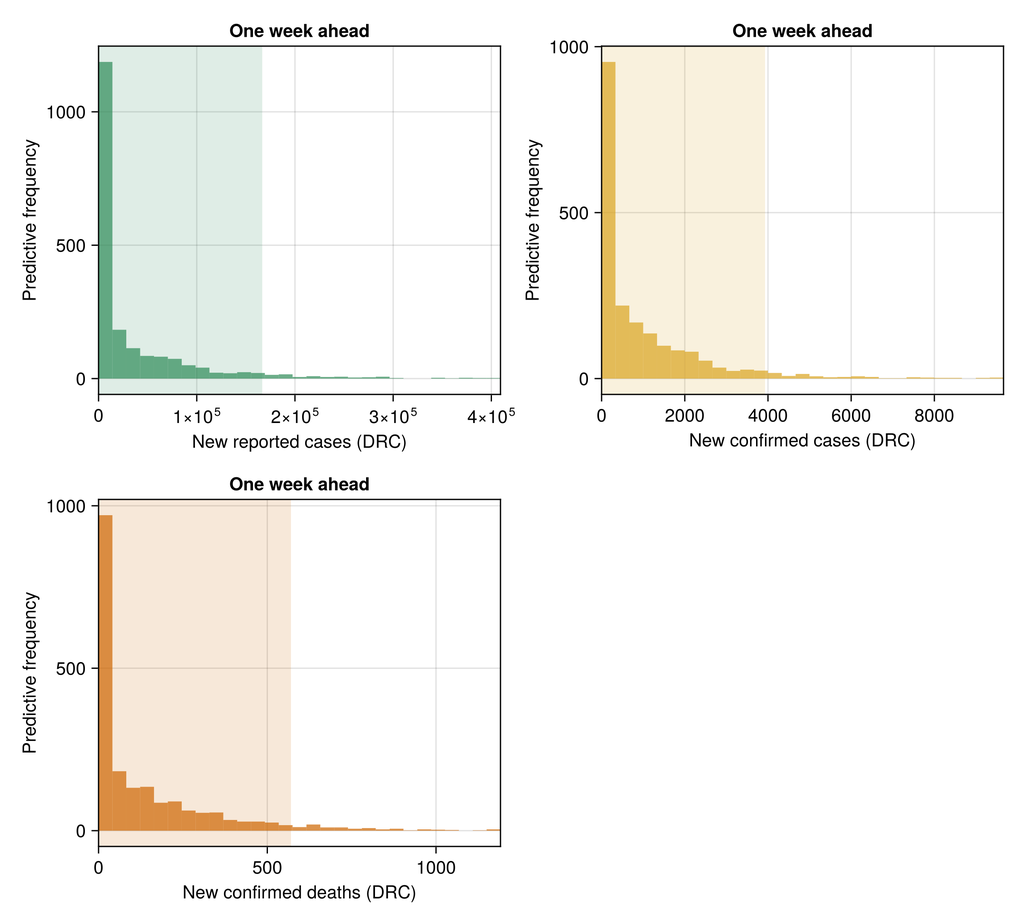

```julia
forecast_fig = plot_forecast(forecast);
```

### Forecast validation (last week versus now)

How last week's forecast held up against the data since observed, using the frozen re-fit and one-week projection defined in the methods forecast-versus-frozen evaluation.

**Fit one week back and validate the one-week-ahead forecast**

julia

```julia
validation_cutoff = string(obs.cutoff - Day(7))
frozen_lastweek = fit_frozen_joint(validation_cutoff)

validation_forecast = forecast_reported(frozen_lastweek.chn;
    horizon = 7,
    obs_cases = frozen_lastweek.o.reported_cases,
    obs_deaths = frozen_lastweek.o.total_deaths,
    obs_confirmed = frozen_lastweek.o.confirmed_cases,
    obs_confirmed_deaths = frozen_lastweek.o.confirmed_deaths);

validation_table = forecast_vs_truth(validation_forecast;
    cases = obs.reported_cases, deaths = obs.total_deaths,
    confirmed = obs.confirmed_cases,
    confirmed_deaths = obs.confirmed_deaths);
```

[output not shown]

4×9 DataFrame

| Row | Stream String | Observed Float64 | Lower 90% Float64 | Lower 60% Float64 | Lower 30% Float64 | Upper 30% Float64 | Upper 60% Float64 | Upper 90% Float64 | Within 90% PI String |
| --- | --- | --- | --- | --- | --- | --- | --- | --- | --- |
| 1 | DRC reported cases | 1077.0 | 249.0 | 1317.0 | 3348.0 | 19454.0 | 59176.0 | 178843.0 | yes |
| 2 | DRC deaths | 246.0 | 18.0 | 126.0 | 246.0 | 683.0 | 1090.0 | 2580.0 | yes |
| 3 | DRC confirmed cases | 550.0 | 29.0 | 187.0 | 393.0 | 1102.0 | 1885.0 | 3785.0 | yes |
| 4 | DRC confirmed deaths | 101.0 | 3.0 | 25.0 | 51.0 | 143.0 | 233.0 | 503.0 | yes |

The observation panels histogram the one-week-ahead cumulative forecast made from the frozen fit, with the 90% predictive interval shaded and the count actually observed by the current cut-off drawn as a dashed black rule.

**Forecast-versus-observed plot**

julia

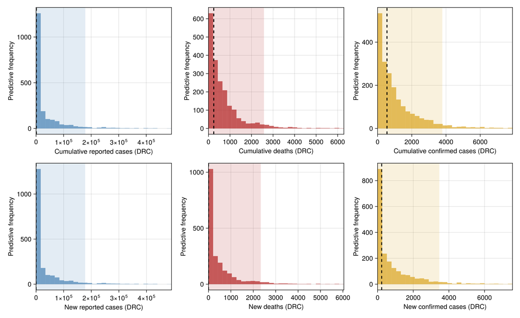

```julia
validation_fig = plot_forecast_vs_truth(validation_forecast;
    cases = obs.reported_cases, deaths = obs.total_deaths,
    confirmed = obs.confirmed_cases,
    baseline_cases = frozen_lastweek.o.reported_cases,
    baseline_deaths = frozen_lastweek.o.total_deaths,
    baseline_confirmed = frozen_lastweek.o.confirmed_cases);
```

The latent quantities are not observed, so they are scored distribution against distribution: what the frozen fit forecast for the past week's new infections, onsets and deaths against what the current fit now estimates for the same window.

**Forecast-versus-now latent plot**

julia

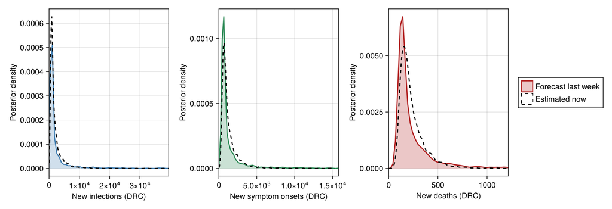

```julia
# Current fit's draws of the new latent counts over the past week, the last
# seven days of each cumulative-trajectory deterministic.
function _now_new(chn, key)
    mat = chn[key]
    trajs = [collect(v) for v in vec(collect(mat))]
    return Float64[t[end] - t[max(1, length(t) - 7)] for t in trajs]
end
now_latent = (;
    infections_new = _now_new(chn_joint, :cumulative_infections),
    onsets_new = _now_new(chn_joint, :cumulative_onsets),
    deaths_latent_new = _now_new(chn_joint, :cumulative_expected_deaths))

validation_latent_fig = plot_forecast_vs_truth_latent(
    validation_forecast; now = now_latent);
```

### Outbreak size estimated by each data stream

Each data stream constrains the latent outbreak size differently. The table below puts the posteriors over the infection count side by side, the single-stream fits and the joint, to show what each stream implies on its own and what the joint adds.

**Per-stream infection-count table**

julia

```julia
streams_C_table = streams_table(
    "exports (cases)" => posterior_C_exports,
    "deaths (DRC)" => posterior_C_deaths,
    "cases (DRC)" => posterior_C_cases,
    "confirmed (DRC)" => posterior_C_confirmed,
    "joint" => posterior_C_joint);
```

5×7 DataFrame

| Row | Stream String | Lower 90% Float64 | Lower 60% Float64 | Lower 30% Float64 | Upper 30% Float64 | Upper 60% Float64 | Upper 90% Float64 |
| --- | --- | --- | --- | --- | --- | --- | --- |
| 1 | exports (cases) | 505.0 | 981.0 | 1403.0 | 2348.0 | 3238.0 | 6015.0 |
| 2 | deaths (DRC) | 1722.0 | 2351.0 | 2907.0 | 4158.0 | 5215.0 | 8298.0 |
| 3 | cases (DRC) | 3429.0 | 4363.0 | 5121.0 | 6863.0 | 8548.0 | 13558.0 |
| 4 | confirmed (DRC) | 7188.0 | 9375.0 | 11303.0 | 16444.0 | 20953.0 | 36657.0 |
| 5 | joint | 2345.0 | 2958.0 | 3498.0 | 5018.0 | 6822.0 | 12421.0 |

**Per-stream projected-trajectory plot**

julia

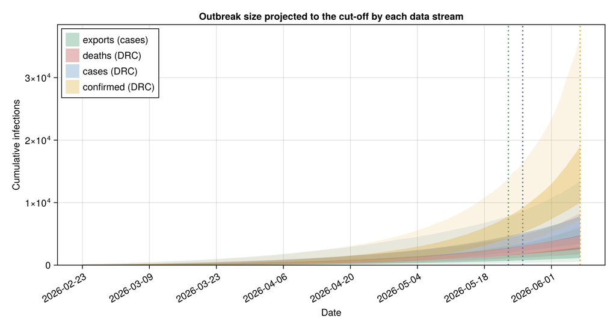

```julia
# Per-draw cumulative-infection trajectory carried by each single-stream
# fit out to the cut-off on day `n`, so streams whose data ends earlier are
# still projected to today.
function _cuminf(chn)
    mat = chn[:cumulative_infections]
    return [collect(v) for v in vec(collect(mat))]
end
# Grid day a stream's data last reports, used for the dotted rule. The
# suspected case and death histories freeze at 26 May; exports and confirmed
# run to the cut-off.
_last_day(days) = isempty(days) ? nothing : maximum(days)

stream_traj_fig = plot_stream_trajectories(
    [
        (; label = "exports (cases)", trajs = _cuminf(chn_exports),
            last_day = _last_day(obs.export_case_days), colour = :seagreen),
        (; label = "deaths (DRC)", trajs = _cuminf(chn_deaths),
            last_day = _last_day(obs.deaths_history.days),
            colour = :firebrick),
        (; label = "cases (DRC)", trajs = _cuminf(chn_cases),
            last_day = _last_day(obs.reported_history.days),
            colour = :steelblue),
        (; label = "confirmed (DRC)", trajs = _cuminf(chn_confirmed),
            last_day = _last_day(obs.confirmed_history.days),
            colour = :goldenrod)];
    n = obs.n, seeding = obs.seeding);
```

The second figure is the posterior density of each fit's cumulative infection count at the cut-off. The confirmed-cases-only stream is ill-defined on its own, so its posterior runs far wider than the rest. The horizontal axis is scaled to a multiple of the joint-fit 90% upper bound, the estimate that constrains every stream together, so the bulk of the joint and the other streams stays visible rather than being flattened by the confirmed-only tail.

**Cut-off infection-count density plot**

julia

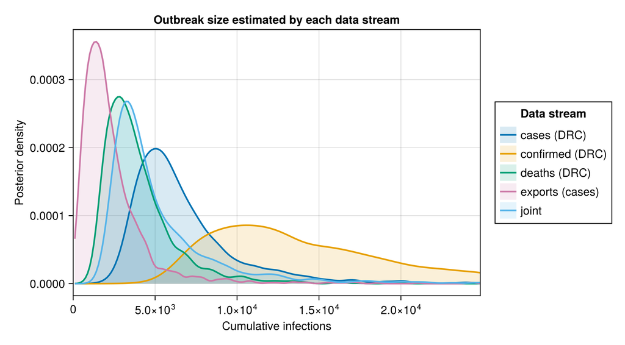

```julia
# Scale the x-axis to twice the joint-fit 90% upper bound, so the joint and
# the streams that track it read clearly while the confirmed-only tail runs
# off the axis rather than dominating it.
density_xmax = 2.0 * quantile(posterior_C_joint, 0.95)

cumulative_density_fig = plot_cumulative_cases(
    "exports (cases)" => posterior_C_exports,
    "deaths (DRC)" => posterior_C_deaths,
    "cases (DRC)" => posterior_C_cases,
    "confirmed (DRC)" => posterior_C_confirmed,
    "joint" => posterior_C_joint;
    scenarios = [], xmax = density_xmax);
```

The frozen re-fits below freeze the renewal data to an earlier cut-off and re-fit, so a later result can be told apart from a later method. Each uses the full headline settings (1000 draws across two chains), reusing the frozen-fit helper defined above.

**Freeze the renewal data to a cut-off and re-fit**

julia

```julia
# Four independent frozen re-fits (one per release vintage); run in parallel.
frozen_20may, frozen_23may,
frozen_26may,
frozen_28may = fit_parallel([
    () -> fit_frozen_joint("2026-05-20"),
    () -> fit_frozen_joint("2026-05-23"),
    () -> fit_frozen_joint("2026-05-26"),
    () -> fit_frozen_joint("2026-05-28")])

frozen_C_20may = vec(Array(frozen_20may.chn[:C_T]))
frozen_C_23may = vec(Array(frozen_23may.chn[:C_T]))
```

[output not shown]

[output not shown]

[output not shown]

[output not shown]

### Estimate evolution across releases

How the outbreak-size estimate moved as the situation reports accrued.

**Released estimates and frozen renewal re-fits**

julia

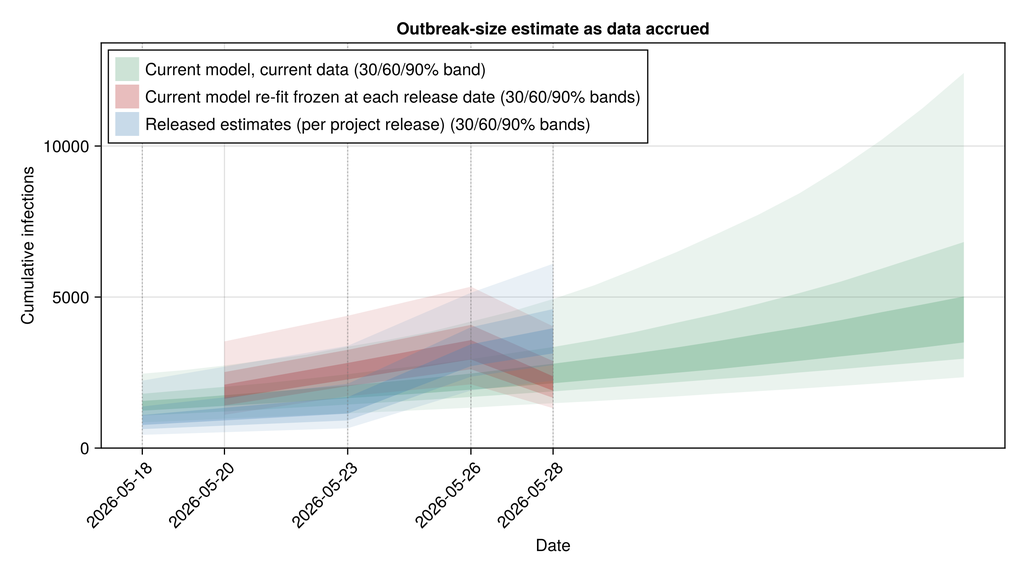

```julia
# Released median and 30/60/90% intervals per data cut-off, recorded from
# each release's published summary (one canonical build per cut-off date:
# builds 241, 350, 470 and 586). These are the integral model's published
# estimates; see the release page for provenance. Each tuple is
# `(date, median, lo30, hi30, lo60, hi60, lo90, hi90)`.
release_evolution = [
    ("2026-05-18", 925, 765, 1095, 628, 1378, 438, 2234),
    ("2026-05-23", 1364, 1142, 1688, 915, 2128, 656, 3385),
    ("2026-05-26", 3041, 2714, 3437, 2364, 4002, 1905, 5144),
    ("2026-05-28", 3510, 3135, 3969, 2750, 4602, 2231, 6103)
]

# The current model evaluated at each past date, the renewal re-fit frozen
# at each cut-off, as a rising series. Each tuple carries the median and
# 30/60/90% credible bounds.
function _ci369(xs)
    q(p) = round(Int, quantile(xs, p))
    (q(0.5), q(0.35), q(0.65), q(0.20), q(0.80), q(0.05), q(0.95))
end
renewal_frozen = [
    (string(frozen_20may.cutoff), _ci369(frozen_C_20may)...),
    (string(frozen_23may.cutoff), _ci369(frozen_C_23may)...),
    (string(frozen_26may.cutoff),
        _ci369(vec(Array(frozen_26may.chn[:C_T])))...),
    (string(frozen_28may.cutoff),
        _ci369(vec(Array(frozen_28may.chn[:C_T])))...)
]

# The current-data, current-model estimate as the cumulative-infection
# trajectory over the day grid (one calendar date per grid day, day 1 is
# the seeding date), summarised by per-day 30/60/90% credible bounds. This
# is the same latent quantity the cumulative-trajectory figure shows, so
# the current estimate rises over time on the release-date axis instead of
# sitting flat. Drawn against calendar dates, it lines up with the
# release and frozen-renewal points.
infection_trajectory = let
    mat = chn_joint[:cumulative_infections]
    trajs = [collect(v) for v in vec(collect(mat))]
    # Only over the comparison window — from the earliest release date to the
    # cut-off — not back to the seeding date.
    start_day = obs.n - value(obs.cutoff - Date(release_evolution[1][1]))
    days = max(start_day, 1):obs.n
    dates = [obs.seeding + Day(d - 1) for d in days]
    q(d, p) = quantile(Float64[t[d] for t in trajs], p)
    (dates,
        [q(d, 0.35) for d in days], [q(d, 0.65) for d in days],
        [q(d, 0.20) for d in days], [q(d, 0.80) for d in days],
        [q(d, 0.05) for d in days], [q(d, 0.95) for d in days])
end

evolution_fig = plot_estimate_evolution(release_evolution;
    renewal = renewal_frozen,
    trajectory = infection_trajectory,
    title = "Outbreak-size estimate as data accrued");
```

### Comparison with McCabe et al.

Earlier versions of this work reimplemented McCabe et al. closely as an exponential-growth model. This version is a discrete-time renewal model with a time-varying reproduction number and every data stream fitted jointly. McCabe et al. published their estimates as scenarios at fixed situation-report cut-offs, each scenario carrying a 95% confidence interval. We show both their reports, the 18 May report and the 20 May update, with those intervals. The two reports share the same geographic-spread scenarios from exported cases and travel volume, so those appear once. Their back-calculation-from-deaths scenarios differ between the reports, since the 18 May report used 88 reported deaths and the 20 May update 131, with a corrected set of case-fatality ratios. McCabe's scenarios estimate cumulative cases at their report dates, though their report is not fully explicit about whether this is symptomatic cases or all infections. We take the like-for-like quantity to be our cumulative symptom onsets, the symptomatic cases, on the same dates, rather than the latent infections (which include the not-yet-symptomatic) or our current cut-off total. We read our value off the joint fit's cumulative-onset trajectory at the grid day for each report date and show it with its credible interval, the 18 May report against our 18 May value and the 20 May update against our 20 May value, so each scenario sits beside our estimate for the date it was made.

**McCabe scenarios with uncertainty against our estimates**

julia

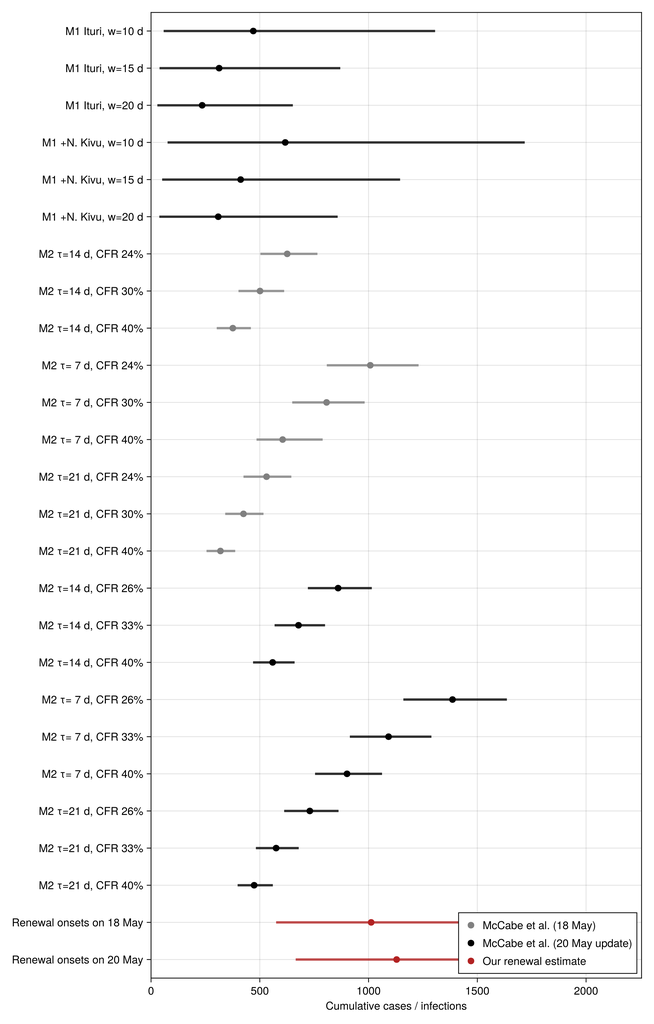

```julia
function _ci90row(xs)
    (round(Int, quantile(xs, 0.5)),
        round(Int, quantile(xs, 0.05)),
        round(Int, quantile(xs, 0.95)))
end

# Our modelled cumulative symptom onsets on a McCabe report date, read off
# the joint fit's per-draw `cumulative_onsets` trajectory. The grid runs to
# the cut-off on day `n`, so the day-index for a date is `n` minus the days
# from that date back to the cut-off (`grid_day("2026-06-07") = n`,
# `"2026-05-20") = n - 18`, `"2026-05-18") = n - 20`).
_onset_trajs = let mat = chn_joint[:cumulative_onsets]
    [collect(v) for v in vec(collect(mat))]
end
# Inverse of `grid_date(day) = obs.cutoff - Day(obs.n - day)`: the day-index
# whose calendar date is `date`, using `value` (imported above) for the
# day count rather than the non-exported `Dates.date2epochdays`.
_grid_day(date) = obs.n - value(obs.cutoff - Date(date))
function _ours_on(date)
    d = _grid_day(date)
    _ci90row(Float64[t[d] for t in _onset_trajs])
end

# McCabe scenarios with their reported 95% confidence intervals, grouped by
# report date, then our modelled cumulative onsets on the matching
# report date with its credible interval.
mccabe_rows = [(label, mean, lo, hi)
               for (_, label, mean, lo, hi) in REPORT_SCENARIOS_CI]
mccabe_groups = [date == "2026-05-18" ? "McCabe et al. (18 May)" :
                 "McCabe et al. (20 May update)"
                 for (date, _, _, _, _) in REPORT_SCENARIOS_CI]

ours_rows = [("Renewal onsets on 18 May", _ours_on("2026-05-18")...),
    ("Renewal onsets on 20 May", _ours_on("2026-05-20")...)]
ours_groups = fill("Our renewal estimate", 2)

matched_rows = vcat(mccabe_rows, ours_rows)
matched_groups = vcat(mccabe_groups, ours_groups)

matched_comparison_fig = plot_estimate_comparison(matched_rows;
    xlabel = "Cumulative cases / infections",
    groups = matched_groups,
    group_colours = ["McCabe et al. (18 May)" => :grey,
        "McCabe et al. (20 May update)" => :black,
        "Our renewal estimate" => :firebrick]);
```

Side-by-side outbreak-size intervals for the two frozen fits and the current-data fit, so the shift with the data cut-off reads off directly.

**Frozen-fit C_T table**

julia

```julia
frozen_streams_table = streams_table(
    "frozen 20 May" => frozen_C_20may,
    "frozen 23 May" => frozen_C_23may,
    "current data" => posterior_C_joint);
```

3×7 DataFrame

| Row | Stream String | Lower 90% Float64 | Lower 60% Float64 | Lower 30% Float64 | Upper 30% Float64 | Upper 60% Float64 | Upper 90% Float64 |
| --- | --- | --- | --- | --- | --- | --- | --- |
| 1 | frozen 20 May | 1103.0 | 1413.0 | 1633.0 | 2101.0 | 2517.0 | 3532.0 |
| 2 | frozen 23 May | 1718.0 | 2051.0 | 2272.0 | 2820.0 | 3252.0 | 4381.0 |
| 3 | current data | 2345.0 | 2958.0 | 3498.0 | 5018.0 | 6822.0 | 12421.0 |

### Delay sensitivity

The death stream dates the outbreak from how far deaths lag symptom onset, so the assumed onset-to-death delay sets the implied infection count. The baseline uses the hospital-pathway delay from the Isiro 2012 line-list reanalysis (onset to admission then admission to death, implied mean about 12 d). We re-fit the joint model under the community-pathway delay from the same reanalysis, the delay for deaths that occur in the community without a recorded admission, which is shorter (implied mean about 8 d). Both pathways come from the line list, so this varies the actual delay assumption rather than an arbitrary scenario. The re-fit uses the full headline settings (1000 draws across two chains).

The infection count to date shifts with the assumed delay, and the table and overlaid densities below show how far.

**Re-fit the joint under the community-pathway onset-to-death delay**

julia

```julia
# One joint re-fit on the live data at the full headline settings, with hooks
# to override the genetic-seeding bound and the deaths submodel. The deaths
# submodel is passed the same way the genetic-seeding override is, as a
# closure matching the joint's `deaths(history, total, onsets, k;
# background_re)` call, so an alternative onset-to-death delay can be injected
# without touching the package.
function refit_joint_variant(;
        deaths = deaths_model,
        tmrca_days = obs.tmrca_days,
        tmrca_days_sd = 15.0,
        samples = 1000, chains = 2)
    chn = nuts_sample(
        bvd_joint(
            obs.n, obs.exported_cases, obs.total_deaths,
            obs.reported_cases, obs.exports_deaths, obs.confirmed_cases,
            obs.tests_analysed;
            confirmed_deaths = obs.confirmed_deaths,
            deaths_history = obs.deaths_history,
            reported_history = obs.reported_history,
            confirmed_history = obs.confirmed_history,
            confirmed_deaths_history = obs.confirmed_deaths_history,
            lab_history = obs.lab_history,
            tests_received_history = obs.tests_received_history,
            export_case_days = obs.export_case_days,
            export_death_days = obs.export_death_days,
            breakpoint = _BREAKPOINT,
            background_re = true,
            confirmed_positivity_link = :composition,
            deaths = deaths,
            genetic = genetic_seeding_model,
            tmrca_days = tmrca_days,
            tmrca_days_sd = tmrca_days_sd);
        samples = samples, chains = chains)
    return chn
end

# Community-pathway onset-to-death delay from the Isiro 2012 line-list
# reanalysis community-death model (a single Gamma, implied mean ≈ 8 d,
# shape ≈ 5.5), a closure that re-injects this delay on its natural Gamma
# shape and scale into the deaths submodel while keeping its other defaults.
deaths_community_delay = (history,
    total,
    onsets,
    k;
    kwargs...) -> deaths_model(history, total, onsets, k;
    onset_to_death = gamma_delay_model(40;
        alpha_prior = truncated(Normal(5.48, 2.0); lower = 0.01),
        theta_prior = truncated(Normal(1.49, 0.5); lower = 0.1)),
    kwargs...)

chn_joint_community_delay = refit_joint_variant(
    deaths = deaths_community_delay)

posterior_C_community_delay = vec(Array(chn_joint_community_delay[:C_T]))
```

[output not shown]

[output not shown]

[output not shown]

[output not shown]

**Delay-sensitivity infection-count table**

julia

```julia
delay_sensitivity_table = streams_table(
    "baseline (hospital pathway)" => posterior_C_joint,
    "community pathway" => posterior_C_community_delay);
```

2×7 DataFrame

| Row | Stream String | Lower 90% Float64 | Lower 60% Float64 | Lower 30% Float64 | Upper 30% Float64 | Upper 60% Float64 | Upper 90% Float64 |
| --- | --- | --- | --- | --- | --- | --- | --- |
| 1 | baseline (hospital pathway) | 2345.0 | 2958.0 | 3498.0 | 5018.0 | 6822.0 | 12421.0 |
| 2 | community pathway | 2104.0 | 2561.0 | 2914.0 | 3804.0 | 4544.0 | 6495.0 |

**Delay-sensitivity infection-count density plot**

julia

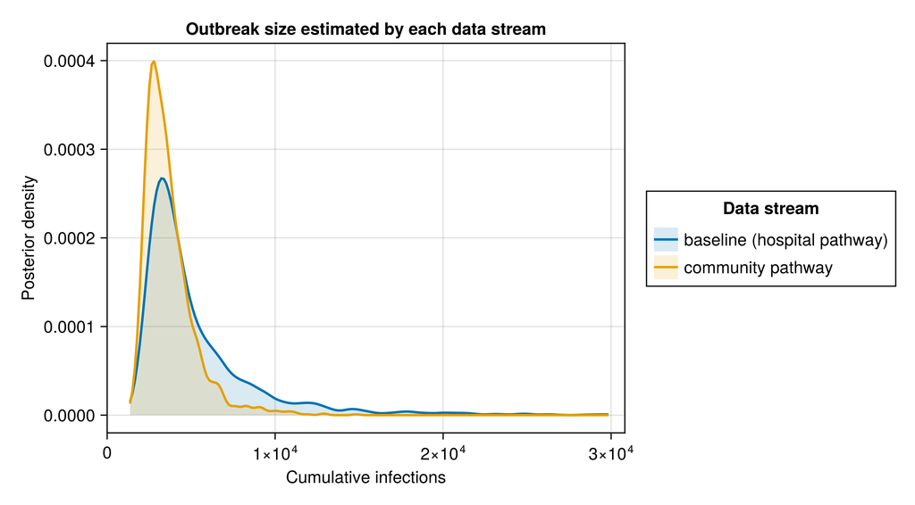

```julia
delay_sensitivity_fig = plot_cumulative_cases(
    "baseline (hospital pathway)" => posterior_C_joint,
    "community pathway" => posterior_C_community_delay;
    scenarios = []);
```